# CAPSTONE : IT SUPPORT TICKET CLASSIFICATION [SEPT SUN GRP 4B]

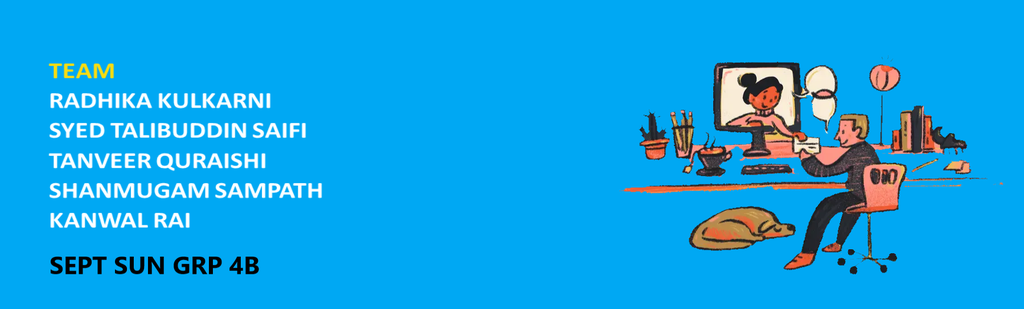

# Capstone Project: Automatic Ticket Assignment

# Aim:

Build a classifier that can classify the tickets by analyzing text. Classify incidents to right functional groups can help organizations to reduce the resolving time of the issue and can focus on more productive tasks.

# Pre-Processing, Data Visualization and EDA

- Exploring the given Data files
- Understanding the structure of data
- Missing points in data
- Finding inconsistencies in the data
- Visualizing different patterns
- Visualizing different text features
- Dealing with missing values
- Text preprocessing
- Creating word vocabulary from the corpus of report text data
- Creating tokens as required

# Model Building

- Building a model architecture which can classify
- Trying different model architectures by researching state of the art for similar tasks
- Train the model
- To deal with large training time, save the weights so that we can use them when training the model for the second time without starting from scratch.

# IMPORT LIBRARIES

```python
import pandas as pd
import numpy as np
import re
import sys
import seaborn as sns
import matplotlib.pyplot as plt
import random
import time

import warnings
import pandas.testing as tm
import spacy
#import langid
import nltk

from wordcloud import WordCloud
from pprint import pprint

from sklearn.utils import resample
from sklearn import preprocessing

from nltk.corpus import stopwords
from nltk.classify.textcat import TextCat
from dateutil import parser
from nltk.tokenize import word_tokenize
#from langdetect import detect
from textblob import TextBlob
#from googletrans import Translator

import gensim
import gensim.corpora as corpora
from gensim.utils import simple_preprocess
from gensim.models.ldamodel import LdaModel
from gensim.models import CoherenceModel
#import pyLDAvis
#import pyLDAvis.gensim

from collections import OrderedDict
#import enchant
#from enchant.checker import SpellChecker

from sklearn.feature_extraction.text import CountVectorizer
import plotly.express as px
from collections import Counter

from gensim.models import Word2Vec
from tensorflow.keras.callbacks import ModelCheckpoint, ReduceLROnPlateau
from tensorflow.keras.layers import Dense, Input, LSTM, Embedding, Dropout, Activation, Flatten, Bidirectional, GlobalMaxPool1D,GRU,Conv1D,MaxPooling1D
from tensorflow.keras.models import Model, Sequential
import tensorflow as tf
from sklearn import metrics
from tensorflow.keras import backend as K
import matplotlib.pyplot as plt
from tensorflow.keras.utils import plot_model
from sklearn.model_selection import train_test_split
from tensorflow.keras.preprocessing.text import Tokenizer
from tensorflow.keras.preprocessing.sequence import pad_sequences

from sklearn.metrics import classification_report
from sklearn.metrics import accuracy_score

import operator

from scipy import spatial
from sklearn.manifold import TSNE

from sklearn.model_selection import train_test_split
from tensorflow.keras.preprocessing.text import Tokenizer
from tensorflow.keras.preprocessing.sequence import pad_sequences
from sklearn import svm
from sklearn.ensemble import RandomForestClassifier
from sklearn.model_selection import GridSearchCV

from sklearn.linear_model import LogisticRegression, SGDClassifier
from sklearn.naive_bayes import MultinomialNB

#warnings.filterwarnings("ignore",category=DeprecationWarning)
#warnings.filterwarnings(action='once')
warnings.filterwarnings('ignore')

plt.style.use('ggplot')
%matplotlib inline
```

```python
np.__version__ , pd.__version__,tf.__version__
```

```
('1.18.5', '1.0.5', '2.3.0')
```

```python
"""
Download required NLTK stopwords corpus if it has not already been downloaded.
Download required NLTK corpora if they have not already been downloaded.
Download the NLTK averaged perceptron tagger that is required for this algorithm to run only if the corpora has not already been downloaded.
Download Punkt Sentence Tokenizer. This tokenizer divides a text into a list of sentences, by using an unsupervised algorithm to build a model for abbreviation words, collocations, and words that start sentences
"""
nltk.download('wordnet', quiet=True)
nltk.download('punkt', quiet=True)
nltk.download('stopwords', quiet=True)
nltk.download('averaged_perceptron_tagger', quiet=True)
```

```
True
```

# DATA LOADING AND PRE-PROCESSING

## DATA LOADING

```python
from google.colab import drive
drive.mount('/content/drive')
```

```
Go to this URL in a browser: https://accounts.google.com/o/oauth2/auth?client_id=947318989803-6bn6qk8qdgf4n4g3pfee6491hc0brc4i.apps.googleusercontent.com&redirect_uri=urn%3aietf%3awg%3aoauth%3a2.0%3aoob&scope=email%20https%3a%2f%2fwww.googleapis.com%2fauth%2fdocs.test%20https%3a%2f%2fwww.googleapis.…

Enter your authorization code:
··········
```

```python
project_path = '/content/drive/My Drive/Colab Notebooks/'
file_name ='input_data.xlsx'
```

```python
data=pd.read_excel(project_path+file_name,encoding=sys.getfilesystemencoding())
data.head()
```

|  | Short description | Description | Caller | Assignment group |
| --- | --- | --- | --- | --- |
| 0 | login issue | -verified user details.(employee# & manager na... | spxjnwir pjlcoqds | GRP_0 |
| 1 | outlook | \r\n\r\nreceived from: hmjdrvpb.komuaywn@gmail... | hmjdrvpb komuaywn | GRP_0 |
| 2 | cant log in to vpn | \r\n\r\nreceived from: eylqgodm.ybqkwiam@gmail... | eylqgodm ybqkwiam | GRP_0 |
| 3 | unable to access hr_tool page | unable to access hr_tool page | xbkucsvz gcpydteq | GRP_0 |
| 4 | skype error | skype error | owlgqjme qhcozdfx | GRP_0 |

```python
data.shape #data.info() , #data[data.columns[0]]
```

```
(8500, 4)
```

# Finding:

- Dataset has 8500 Documents(records) and 4 features(columns).
- Dataset : Dataset Structure (4 Variables, 8500 Incident Records): Caller, Short Description, Description and Assignment Group
- 8 Titles and 1 Description is null.

## DATA DUPLICATION : DROP BY DESCRIPTION & GROUP CRITERIA

```python
print("Duplicate Rows except first occurrence based on (1) all columns, (2) description, (3) description and group")
len(data[data.duplicated()]), len(data[data.duplicated([data.columns[1]])]), len(data[data.duplicated([data.columns[1], data.columns[3]])])
```

```
Duplicate Rows except first occurrence based on (1) all columns, (2) description, (3) description and group
```

```
(83, 682, 661)
```

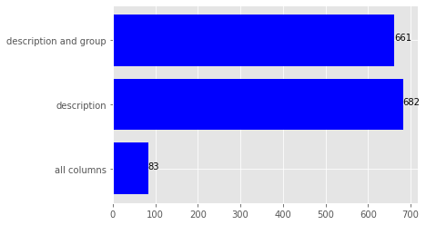

```python
ls=[len(data[data.duplicated()]), len(data[data.duplicated([data.columns[1]])]), len(data[data.duplicated([data.columns[1], data.columns[3]])])]
ls_ttle =["all columns","description", "description and group"]
plt.barh(ls_ttle, ls, color ='b')
for index, value in enumerate(ls):
    plt.text(value, index, str(value))
```

# Finding:

- Duplicate Rows except first occurrence based on:
- Description and Group: 661
- Description: 682
- All columns: 83

```python
data.shape
```

```
(8500, 4)
```

# Removing duplicated records based on Description and Group columns

```python
data = data.drop_duplicates(subset=[data.columns[1], data.columns[3]], keep='first')
```

```python
data.shape
```

```
(7839, 4)
```

- Note: After removing the duplicated records based on description and group column, total number of records are 7839.

## DATA MODE AND MISSING VALUES

```python
for i in enumerate(data.columns):
    print(i[0], i[1],': Total Records :', data[i[1]].shape)
    print(i[0], i[1],': Unique Value Count :', data[i[1]].unique().shape)
    print(i[0], i[1],': Null Value Count :', len(data[data[i[1]].isna()]))
    print(i[0], i[1],': Space Value Count :', (data[i[1]] == '').sum(axis=0))
    print(i[0], i[1],': Mode Value :', data[i[1]].mode()[0])
    print(i[0], i[1],': Mode Value Count :', data[i[1]].value_counts(ascending=True).max())
    print(i[0], i[1],': Non-Empty Value Count : ', len( data.loc[data[i[1]].str.len() > 0].index) )
    print()
    print("-----------------------------------------------------------------------------------------------------")

print(data[data.columns[3]].value_counts().mean())
print()
print(data[data.columns[3]].value_counts(normalize=True))
print()
print(data[data.columns[3]].value_counts()[:10], data[data.columns[3]].value_counts()[:10].sum())
print()
print(data[data.columns[3]].value_counts()[-10:], data[data.columns[3]].value_counts()[-10:].sum())
print()
print(data[data.columns[3]].value_counts()[:50].sum(), data[data.columns[3]].value_counts()[-24:].sum(), data[data.columns[3]].value_counts()[:50].sum() + data[data.columns[3]].value_counts()[-24:].sum())
print()
print("-----------------------------------------------------------------------------------------------------")
iii=[]
for ii in range(0,len(data.columns),1):
    print(ii,
          data.columns[ii],
          len(data.loc[data[data.columns[ii]].str.len() > 0].index),
          len(data.loc[~(data[data.columns[ii]].str.len() > 0)].index))
    for i in data.loc[~(data[data.columns[ii]].str.len() > 0)].index:
        iii.append(i)
        print(i,data.loc[i][ii])
print("-----------------------------------------------------------------------------------------------------")
print(len(set(iii)))
print(iii)
print("-----------------------------------------------------------------------------------------------------")
print(': Describe Target Class :', data[data.columns[3]].value_counts(ascending=True).describe())
```

```
0 Short description : Total Records : (7839,)
0 Short description : Unique Value Count : (7420,)
0 Short description : Null Value Count : 5
0 Short description : Space Value Count : 0
0 Short description : Mode Value : erp access issue
0 Short description : Mode Value Count : 17
0 Short description : Non-Empty Value Count :  7834

-----------------------------------------------------------------------------------------------------
1 Description : Total Records : (7839,)
1 Description : Unique Value Count : (7818,)
1 Description : Null Value Count : 1
1 Description : Space Value Count : 0
1 Description : Mode Value : account locked.
1 Description : Mode Value Count : 3
1 Description : Non-Empty Value Count :  7838

-----------------------------------------------------------------------------------------------------
2 Caller : Total Records : (7839,)
2 Caller : Unique Value Count : (2736,)
2 Caller : Null Value Count : 0
2 Caller : Space Value Count : 0
2 Caller : Mode Value : bpctwhsn kzqsbmtp
2 Caller : Mode Value Count : 788
2 Caller : Non-Empty Value Count :  7839

-----------------------------------------------------------------------------------------------------
3 Assignment group : Total Records : (7839,)
3 Assignment group : Unique Value Count : (74,)
3 Assignment group : Null Value Count : 0
3 Assignment group : Space Value Count : 0
3 Assignment group : Mode Value : GRP_0
3 Assignment group : Mode Value Count : 3410
3 Assignment group : Non-Empty Value Count :  7839

-----------------------------------------------------------------------------------------------------
105.93243243243244

GRP_0     0.435004
GRP_8     0.082281
```

[output cut: 46 more lines]

```
2 Caller 7839 0
3 Assignment group 7839 0
-----------------------------------------------------------------------------------------------------
6
[2604, 3383, 3906, 3924, 4341, 4395]
-----------------------------------------------------------------------------------------------------
: Describe Target Class : count      74.000000
mean      105.932432
std       401.498301
min         1.000000
25%         5.250000
50%        25.500000
75%        81.000000
max      3410.000000
Name: Assignment group, dtype: float64
```

Notes:

```python
data[data.columns[0]].fillna(value=' ', inplace=True)
```

```python
data[data.columns[1]].fillna(value=' ', inplace=True)
```

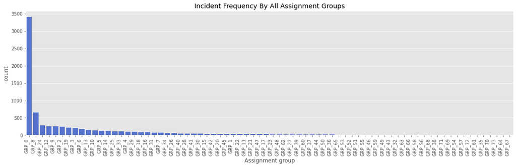

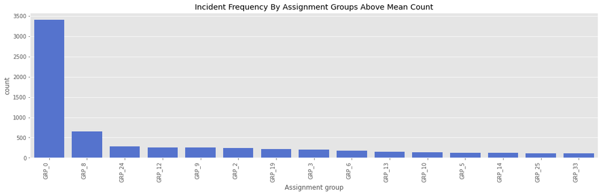

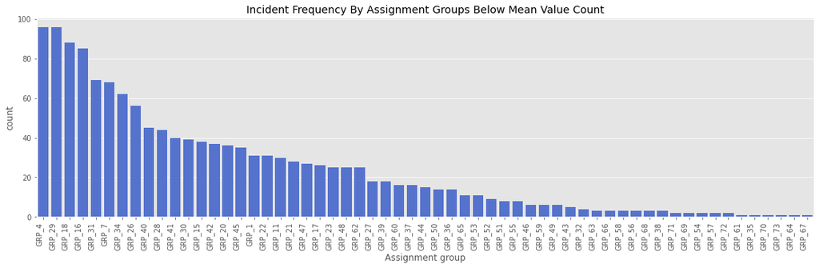

```python
a_a_grp=data[data.columns[3]].value_counts().sort_values(ascending=False).index
#a_m_a_grp

a_m_a_grp=[]
b_m_a_grp=[]

for i in a_a_grp :
    if (data[data[data.columns[3]]==i].count()[0] ) >= data[data.columns[3]].value_counts().mean():
        a_m_a_grp.append(i)
    else :
        b_m_a_grp.append(i)

c_a_grp=[a_a_grp,a_m_a_grp,b_m_a_grp] #print (len (a_a_grp),len(a_m_a_grp),len(b_m_a_grp))
c_a_grp_ttle=["Incident Frequency By All Assignment Groups",
              "Incident Frequency By Assignment Groups Above Mean Count",
              "Incident Frequency By Assignment Groups Below Mean Value Count"]

ii=0

while ii<3 :
    plt.subplots(figsize=(19,5))
    ax=sns.countplot(x=data.columns[3],
                 data=data,
                 orient="v",
                 color='royalblue',
                 order=c_a_grp[ii])
    ax.set_xticklabels(ax.get_xticklabels(),
                       rotation=90,
                       ha="right")
    ax.set_title(c_a_grp_ttle[ii])
    plt.show()
    ii=ii+1
```

```python
len(data[data.columns[3]].unique())
```

```
74
```

```python
data[data.columns[3]].value_counts()
```

```
GRP_0     3410
GRP_8      645
GRP_24     284
GRP_12     256
GRP_9      252
          ...
GRP_73       1
GRP_61       1
GRP_35       1
GRP_70       1
GRP_67       1
Name: Assignment group, Length: 74, dtype: int64
```

```python
_DF=data.groupby([data.columns[3]]).size()
_DF
```

```
Assignment group
GRP_0     3410
GRP_1       31
GRP_10     140
GRP_11      30
GRP_12     256
          ...
GRP_71       2
GRP_72       2
GRP_73       1
GRP_8      645
GRP_9      252
Length: 74, dtype: int64
```

Notes :

## DATA LABEL : RE-CLASSIFICATION (NEW ASSIGNMENT GROUP)

```python
data.shape, print(data.columns[3])
```

```
Assignment group
```

```
((7839, 4), None)
```

```python
data.head(2).T
```

|  | 0 | 1 |
| --- | --- | --- |
| Short description | login issue | outlook |
| Description | -verified user details.(employee# & manager na... | \r\n\r\nreceived from: hmjdrvpb.komuaywn@gmail... |
| Caller | spxjnwir pjlcoqds | hmjdrvpb komuaywn |
| Assignment group | GRP_0 | GRP_0 |

```python
m_i_cnt=0 #Minimum Incidents Crieria For To Be An Independent Class Else Aggregate
s_a_grps=[]
for i in data[data.columns[3]].unique():
    if(data.groupby(data.columns[3])[data.columns[3]].value_counts()[i][0]<m_i_cnt):
        s_a_grps.append(i)
```

```python
len(s_a_grps),s_a_grps
```

```
(0, [])
```

```python
#data[ data[data.columns[3]].isin( s_a_grps ) ].columns[3]
#micnt= data[ data[data.columns[3]].isin( s_a_grps ) ]
#order=micnt[micnt.columns[3]].value_counts().sort_values(ascending=False).index
```

```python
print('Groups Having Number of Incident Frequency less than threshold criteri of {} incidents per group'.format(m_i_cnt))
if len(s_a_grps) >0:
    plt.subplots(figsize=(19,5))
    ax=sns.countplot(x=data[ data[data.columns[3]].isin( s_a_grps )].columns[3],
                 data=data[ data[data.columns[3]].isin( s_a_grps ) ],
                 color='royalblue',
                 order= data[ data[data.columns[3]].isin( s_a_grps ) ][data[ data[data.columns[3]].isin( s_a_grps ) ].columns[3]].value_counts().sort_values(ascending=False).index
                )
    ax.set_xticklabels(ax.get_xticklabels(), rotation=90, ha="center")
    ax.set_title('Assignment Groups Less Than Threshold Incident Value')
    plt.show()
```

```
Groups Having Number of Incident Frequency less than threshold criteri of 0 incidents per group
```

```python
print('Regrouping {} assignment groups under a new group which have incident frequency under minimum count of {}'.format(len(s_a_grps), m_i_cnt))
```

```
Regrouping 0 assignment groups under a new group which have incident frequency under minimum count of 0
```

```python
data['New_Assignment_Groups'] = data[data.columns[3]]
```

```python
data[data.columns[4]] = data[data.columns[4]].apply(lambda x : 'GRP_M_I_CNT' if x in s_a_grps else x)
```

```python
data.head()
```

|  | Short description | Description | Caller | Assignment group | New_Assignment_Groups |
| --- | --- | --- | --- | --- | --- |
| 0 | login issue | -verified user details.(employee# & manager na... | spxjnwir pjlcoqds | GRP_0 | GRP_0 |
| 1 | outlook | \r\n\r\nreceived from: hmjdrvpb.komuaywn@gmail... | hmjdrvpb komuaywn | GRP_0 | GRP_0 |
| 2 | cant log in to vpn | \r\n\r\nreceived from: eylqgodm.ybqkwiam@gmail... | eylqgodm ybqkwiam | GRP_0 | GRP_0 |
| 3 | unable to access hr_tool page | unable to access hr_tool page | xbkucsvz gcpydteq | GRP_0 | GRP_0 |
| 4 | skype error | skype error | owlgqjme qhcozdfx | GRP_0 | GRP_0 |

```python
len(data.groupby(data.columns[3])[data.columns[3]].unique()), len(data.groupby(data.columns[4])[data.columns[4]].unique())
```

```
(74, 74)
```

```python
data.shape
```

```
(7839, 5)
```

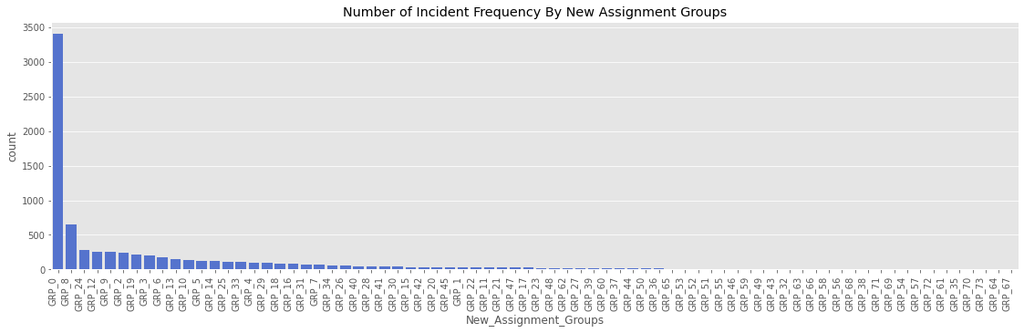

```python
#data[data.columns[4]].unique(), len(data[data.columns[4]].unique()), #data.head()
#print(data[data.columns[4]].value_counts().sort_values(ascending=False).index)
plt.subplots(figsize=(19,5))
ax=sns.countplot(x=data.columns[4], data=data, color='royalblue',order=data[data.columns[4]].value_counts().sort_values(ascending=False).index)
ax.set_xticklabels(ax.get_xticklabels(), rotation=90, ha="right")
ax.set_title('Number of Incident Frequency By New Assignment Groups')
plt.show()
```

## TEXT LENGTH [NEW COLUMN]

```python
data.head(2).T
```

|  | 0 | 1 |
| --- | --- | --- |
| Short description | login issue | outlook |
| Description | -verified user details.(employee# & manager na... | \r\n\r\nreceived from: hmjdrvpb.komuaywn@gmail... |
| Caller | spxjnwir pjlcoqds | hmjdrvpb komuaywn |
| Assignment group | GRP_0 | GRP_0 |
| New_Assignment_Groups | GRP_0 | GRP_0 |

### Analysing text lenght for description column

```python
data['Text_length']=[len(text) for text in data[data.columns[1]]]
data.head(2).T
```

|  | 0 | 1 |
| --- | --- | --- |
| Short description | login issue | outlook |
| Description | -verified user details.(employee# & manager na... | \r\n\r\nreceived from: hmjdrvpb.komuaywn@gmail... |
| Caller | spxjnwir pjlcoqds | hmjdrvpb komuaywn |
| Assignment group | GRP_0 | GRP_0 |
| New_Assignment_Groups | GRP_0 | GRP_0 |
| Text_length | 206 | 194 |

```python
data.shape
```

```
(7839, 6)
```

```python
data[data.columns[5]].describe()
```

```
count     7839.000000
mean       217.636051
std        538.579024
min          1.000000
25%         49.000000
50%        106.000000
75%        212.500000
max      13001.000000
Name: Text_length, dtype: float64
```

## DATA SUFFICIENCY : DROP BY MINIMUM TEXT LENGTH CRITERIA

```python
data.shape
```

```
(7839, 6)
```

```python
min_t_cnt=0
mask_1= data[data.columns[5]] <= min_t_cnt #mask_1 for less than or same as min text length
mask_2= data[data.columns[5]] > min_t_cnt #mask_2 for above min text length
data.shape[0],len(data[mask_1]), len(data[mask_2])
```

```
(7839, 0, 7839)
```

```python
data.head(2).T
```

|  | 0 | 1 |
| --- | --- | --- |
| Short description | login issue | outlook |
| Description | -verified user details.(employee# & manager na... | \r\n\r\nreceived from: hmjdrvpb.komuaywn@gmail... |
| Caller | spxjnwir pjlcoqds | hmjdrvpb komuaywn |
| Assignment group | GRP_0 | GRP_0 |
| New_Assignment_Groups | GRP_0 | GRP_0 |
| Text_length | 206 | 194 |

```python
data=data[mask_2]
```

```python
data.shape
```

```
(7839, 6)
```

```python
data[data.columns[1]]=data[data.columns[1]].apply(lambda x : " ".join([text for text in x.split() if(len(text) > min_t_cnt-1)]))
data.shape
```

```
(7839, 6)
```

```python
data.shape, len(data[data[data.columns[5]] > min_t_cnt]), len(data[data[data.columns[5]] <= min_t_cnt])
```

```
((7839, 6), 7839, 0)
```

```
Length of Texts By Incidents Across Assignment Groups
```

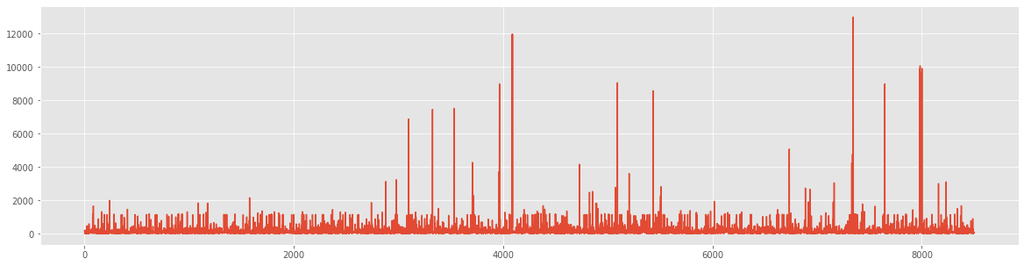

```python
print('Length of Texts By Incidents Across Assignment Groups')
plt.subplots(figsize=(20,5))
ax=plt.plot(data[data.columns[5]])
plt.show()
```

```python
data.head(2).T
```

|  | 0 | 1 |
| --- | --- | --- |
| Short description | login issue | outlook |
| Description | -verified user details.(employee# & manager na... | received from: hmjdrvpb.komuaywn@gmail.com hel... |
| Caller | spxjnwir pjlcoqds | hmjdrvpb komuaywn |
| Assignment group | GRP_0 | GRP_0 |
| New_Assignment_Groups | GRP_0 | GRP_0 |
| Text_length | 206 | 194 |

### Viewing top ten assignment groups

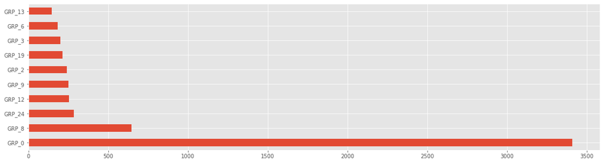

```python
#data[data.columns[4]].value_counts()[:45]
data[data.columns[4]].value_counts(ascending=False, sort=True)[:10].plot(kind='barh' , figsize=(19, 5), rot=0) # top 10 assignment groups
```

### Analysing groups and word counts in description column

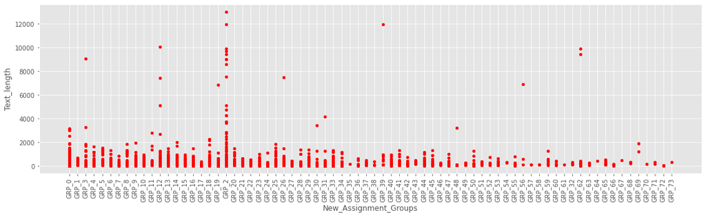

```python
data.plot(x=data.columns[4],y=data.columns[5],kind='scatter',color='r', figsize=(19, 5), rot=90)
```

## MERGING SHORT DESCRIPTION and DESCRIPTION

```python
# data.reset_index(drop=True,inplace=True)
"""
# data[data.columns[1]] = data[data.columns[1]].str.strip()
# data[data.columns[1]] = data[data.columns[1]].str.lower()
# data[data.columns[1]] = data[data.columns[1]].str.split().apply(lambda x:OrderedDict.fromkeys(x).keys()).str.join(' ')
# data.info()
"""
# Merge the Short description and Description columns

data['Description'] = data['Short description'].str.cat(data['Description'], sep=' ', na_rep=' ')
```

[output not shown]

Notes:

```python
data.head(2).T
```

|  | 0 | 1 |
| --- | --- | --- |
| Short description | login issue | outlook |
| Description | -verified user details.(employee# & manager na... | received from: hmjdrvpb.komuaywn@gmail.com hel... |
| Caller | spxjnwir pjlcoqds | hmjdrvpb komuaywn |
| Assignment group | GRP_0 | GRP_0 |
| New_Assignment_Groups | GRP_0 | GRP_0 |
| Text_length | 206 | 194 |

```
Length of Texts By Incidents Across Assignment Groups
```

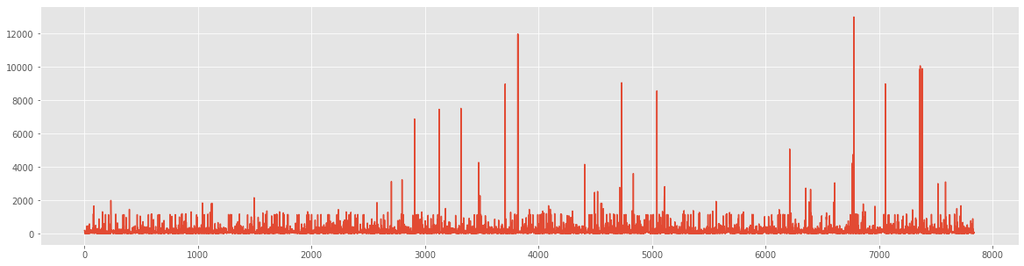

```python
print('Length of Texts By Incidents Across Assignment Groups')
plt.subplots(figsize=(20,5))
ax=plt.plot(data[data.columns[5]])
plt.show()
```

# DATA CLEANING

## PRE-PROCESSED MODEL DATA

```python
data.head(2).T
```

|  | 0 | 1 |
| --- | --- | --- |
| Short description | login issue | outlook |
| Description | -verified user details.(employee# & manager na... | received from: hmjdrvpb.komuaywn@gmail.com hel... |
| Caller | spxjnwir pjlcoqds | hmjdrvpb komuaywn |
| Assignment group | GRP_0 | GRP_0 |
| New_Assignment_Groups | GRP_0 | GRP_0 |
| Text_length | 206 | 194 |

```python
data.shape
```

```
(7839, 6)
```

## TEXT CLEANING : USING REGULAR EXPRESSION METHOD

Important:

```python
def is_valid_date(date_str):
    try:
        parser.parse(date_str)
        return True
    except:
        return False
```

```python
def clean_data(text):
    text = text.lower()

    text = ' '.join([w for w in text.split() if not is_valid_date(w)])

    text = re.sub(r"received from:",' ',text)
    text = re.sub(r"_", ' ', text)

    password_list = ["pwd", "psswords", "psswod", "pssword"]
    password = "password"
    text = ' '.join([password if word in password_list else word for word in text.split()])

    text = re.sub('((www\.[^\s]+)|(https?://[^\s]+))','URL', text)
    text = re.sub('@[^\s]+','USER', text)
    text = text.lower().replace("ё", "е")
    text = re.sub('[^a-zA-Zа-яА-Я1-9]+', ' ', text)
    text = re.sub(' +',' ', text)

    text = re.sub("(\\d|\\W)+"," ",text)
    text = re.sub(r"from:",' ',text)
    text = re.sub(r"to:",' ',text)
    text = re.sub(r"subject:",' ',text)
    text = re.sub(r"sent:",' ',text)
    text = re.sub(r"ic:",' ',text)
    text = re.sub(r"cc:",' ',text)
    text = re.sub(r"bcc:",' ',text)
    text = re.sub(r'\S*@\S*\s?', '', text)
    text = re.sub(r'\d+','' ,text)
    text = re.sub(r'\n',' ',text)
    #text = re.sub(r'\t',' ',text)
    text = re.sub(r'#','', text)
    text = re.sub(r'&;?', 'and',text)
    text = re.sub(r'\&\w*;', '', text)
    text = re.sub(r'https?:\/\/.*\/\w*', '', text)
    text= ''.join(c for c in text if c <= '\uFFFF')
    text = text.strip()
    text = ' '.join(re.sub("[^\u0030-\u0039\u0041-\u005a\u0061-\u007a]", " ", text).split())

    for i in data.columns[2]:
        for j in [p for p in i.split()]:
            text = text.replace(j,'')

    text = re.sub(r"\s+[a-zA-Z]\s+", ' ', text)
    text = re.sub(' +', ' ', text)

    text = text.strip()

    return text
```

```python
start = time.time()
data[data.columns[1]].apply(clean_data)
time.sleep(1)
end = time.time()
print(f"Time Taken To Clean Data : {end - start}")
data.shape
```

```
Time Taken To Clean Data : 5.306733131408691
```

```
(7839, 6)
```

## MULTI-LINGUAL TEXT: USING LANGUAGE TRANSLATION [OPTIONAL]

```python
non_en_txt = ['nicht', 'bitte']
non_en_txt_list = '|'.join(non_en_txt)
non_en_txt_list
```

```python
non_en_txt_Index = data[data[data.columns[1]].str.contains(non_en_txt_list)].index
print(non_en_txt_Index)
len(non_en_txt_Index), data[data.columns[1]].iloc[non_en_txt_Index[0]], #data[data.columns[1]][265]
```

```python
def text_translation(non_en_txt):
    translator =Translator()
    if translator.detect(non_en_txt).lang != 'en':
        en_text = translator.translate(non_en_txt).text
    else:
        en_text = non_en_txt
    return en_text
```

```python
start = time.time()

#for i in non_en_txt_Index:
 #   data[ data.columns[1] ][i] = text_translation( data[ data.columns[1] ][i] )

time.sleep(1)
end = time.time()

print(f"Time Taken To Translate Non-English Text : {end - start}")
```

```python
len(non_en_txt_Index), data[data.columns[1]].iloc[non_en_txt_Index[0]]
```

```python
data.reset_index(drop=True,inplace=True)

data[data.columns[1]] = data[data.columns[1]].str.strip()
data[data.columns[1]] = data[data.columns[1]].str.lower()

data[data.columns[1]]=data[data.columns[1]].str.split().apply(lambda x:OrderedDict.fromkeys(x).keys()).str.join(' ')
data.info()
```

## LEMMATISATION + STOP WORDS REMOVAL

```python
idx= random.randint(0,data.shape[0]) #6758, 5716
print(idx, data[data.columns[1]][idx])
```

```
98 received from: noscwdpm.akiowsmp@gmail.com hello, he is an kiosk user. please reset the password and confirm. noscwdpm akiowsmp ihkolepb ozhnjyef sent: 29 october 2016 13:38 to: company@ticketing_tool.com subject: ess portal access issue hi, below mentioned employee krlszbqo spimolgz with user id…
```

```python
sw = stopwords.words('english')
start = time.time()
for i,text in enumerate(data[data.columns[1]]):
    data[data.columns[1]][i]=" ".join(w for w in text.split(' ') if w not in sw)
time.sleep(1)
end = time.time()
print(f"Time Taken To Remove Stop Words From Data : {end - start}")
```

```
Time Taken To Remove Stop Words From Data : 2.0662636756896973
```

```python
nlp = spacy.load('en', disable=['parser', 'ner'])
allowed_postags=['NOUN', 'ADJ', 'VERB', 'ADV']
def lemmatize_text(text):
    doc = nlp(text)
    return ' '.join([token.lemma_ for token in doc])
start = time.time()
data[data.columns[1]] = data[data.columns[1]].apply(lemmatize_text)
time.sleep(1)
end = time.time()
print(f"Time Taken To Lemmatise Data : {end - start}")
```

```
Time Taken To Lemmatise Data : 21.250840663909912
```

```python
data.shape
```

```
(7839, 6)
```

### Language & Spelling Errors & Lemmatization:

Note: We have kept the text as it is. However for experimentation and learning perspective we have tried to translate some of the words from non-English to English. We have also tried correcting some of the typical spelling errors. We have then used lemmatization on the processed or clean text. Lemmatization was carried out subsequently before tokenization for vectorization using word embeddings. We limited ourselves to use lemmatization instead of stemming based on the quality of the data to avoid further dilution of the input feeds. Spacy was used for lemmatization. PyLDAvis was used to plot the topics and analyze the texts using N-Gram models for clustering relevant data using Gensim. This section will stay as an ongoing improvement area of activity for the team till the end of the project.

## IMPROVING READABILITY: SPELLING CORRECTIONS [OPTIONAL]

```python
data.head(2).T
```

```python
word_tokens= [word_tokenize(art) for art in data[data.columns[1]].values]
word_tokens[0]
```

```python
len(word_tokens), len(word_tokens[0]), detect(word_tokens[0][0]), word_tokens[0][0]
```

```python
a_a_grp=data[data.columns[3]].value_counts().sort_values(ascending=False).index
```

```python
len(data[data.columns[1]]), len(data[data.columns[1]][0])
```

```python
max_error_count = 4
min_text_length = 3

def is_in_english(text):
    d = SpellChecker("en_US")
    d.set_text(text)
    errors = [err.word for err in d]
    return False if ((len(errors) > max_error_count) or len(text.split()) < min_text_length) else True
```

```python
data[data.columns[1]][0]
```

```python
print(is_in_english(data[data.columns[1]][0]))
```

```python
non_eng=[]
```

```python
for i in range(0,len(data[data.columns[1]]),1):
    #print (i)
    if (len(data[data.columns[1]][i])> 0) and is_in_english(data[data.columns[1]][i])==False:
        non_eng.append(i)
print(len(non_eng))
```

```python
data[data.columns[1]][non_eng[34]]
```

# TOPIC MODELLING

Typically in a text domain, EDA can have many meanings: What are the topics? How frequent they are? The process will involve some level of preprocessing steps. We analyzed the incidents based on the number of words present in them. We plan to extend its utility in dimensionality reduction in next iteration. Before doing topic modeling and visualisation, we have also looked into word clouds on most common words or bi grams and tri-grams. we have limited the n value to 3 based on the text length analysis as conducted earlier in the data pre-processing stage. We are also going to use this activity to check which all regular expressions are not working properly or which all patterns are still exising in the word cloud in a prominent manner.

## TEXT DATA + WORD CLOUD

```python
data.reset_index(drop=True, inplace =True)
```

```python
data.tail(3).T
```

|  | 7836 | 7837 | 7838 |
| --- | --- | --- | --- |
| Short description | vip2: windows password reset for tifpdchb pedx... | machine não está funcionando | an mehreren pc`s lassen sich verschiedene prgr... |
| Description | vip2 : windows password reset tifpdchb pedxruyf | unable access machine utility finish drawer ad... | mehreren pc`s lassen sich verschiedene prgramd... |
| Caller | oybwdsgx oxyhwrfz | ufawcgob aowhxjky | kqvbrspl jyzoklfx |
| Assignment group | GRP_0 | GRP_62 | GRP_49 |
| New_Assignment_Groups | GRP_0 | GRP_62 | GRP_49 |
| Text_length | 50 | 103 | 82 |

```python
data.shape, len(data[data.columns[1]]), len(data[data.columns[1]].values)
```

```
((7839, 6), 7839, 7839)
```

```python
data[data.columns[1]]
```

```
0       -verified user details.(employee # & manager n...
1       receive from : hmjdrvpb.komuaywn@gmail.com hel...
2       receive from : eylqgodm.ybqkwiam@gmail.com hi ...
3                              unable access hr_tool page
4                                             skype error
                              ...
7834    receive from : avglmrts.vhqmtiua@gmail.com goo...
7835                             telephony_software issue
7836      vip2 : windows password reset tifpdchb pedxruyf
7837    unable access machine utility finish drawer ad...
7838    mehreren pc`s lassen sich verschiedene prgramd...
Name: Description, Length: 7839, dtype: object
```

```python
all_text=data[data.columns[1]].values.tolist()
len(all_text), all_text[0]
```

```
(7839,
 '-verified user details.(employee # & manager name ) -checked name ad reset password . -advised login check . -caller confirm able login . -issue resolve .')
```

```python
def sent_to_words(sentences):
    for sentence in sentences:
        yield(gensim.utils.simple_preprocess(str(sentence), deacc=True))  # deacc=True removes punctuations

text_words = list(sent_to_words(all_text))
```

```python
print(text_words[0])
```

```
['verified', 'user', 'details', 'employee', 'manager', 'name', 'checked', 'name', 'ad', 'reset', 'password', 'advised', 'login', 'check', 'caller', 'confirm', 'able', 'login', 'issue', 'resolve']
```

## BI-GRAMS [WORD CLOUD]

```python
bigram = gensim.models.Phrases(text_words, min_count=5, threshold=100)
```

```python
bigram_mod = gensim.models.phrases.Phraser(bigram)
```

```python
print(bigram_mod[text_words[0]])
```

```
['verified', 'user', 'details_employee', 'manager', 'name', 'checked', 'name', 'ad', 'reset', 'password', 'advised', 'login', 'check', 'caller_confirm', 'able', 'login', 'issue', 'resolve']
```

```python
def make_bigrams(texts):
    return [bigram_mod[doc] for doc in texts]
```

```python
text_words_bigrams = make_bigrams(text_words)
print(text_words_bigrams[0])
```

```
['verified', 'user', 'details_employee', 'manager', 'name', 'checked', 'name', 'ad', 'reset', 'password', 'advised', 'login', 'check', 'caller_confirm', 'able', 'login', 'issue', 'resolve']
```

```python
text_words_bigrams_wc=' '.join(map(str, text_words_bigrams))
```

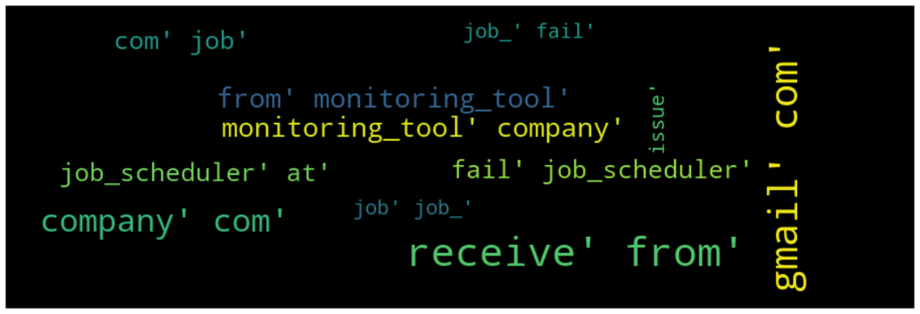

```python
wc = WordCloud(width=900, height=300, max_font_size=40, max_words=100, min_font_size=20).generate(text_words_bigrams_wc)
plt.figure(figsize=(20,10))
plt.imshow(wc, interpolation="bilinear")
plt.axis("off")
plt.margins(x=0, y=0)
plt.show()
```

## TRI-GRAMS [WORD CLOUD]

```python
trigram = gensim.models.Phrases(bigram[text_words], threshold=100)
```

```python
trigram_mod = gensim.models.phrases.Phraser(trigram)
```

```python
print(trigram_mod[bigram_mod[text_words[0]]])
```

```
['verified', 'user', 'details_employee_manager', 'name', 'checked', 'name', 'ad', 'reset', 'password', 'advised', 'login', 'check', 'caller_confirm_able', 'login', 'issue', 'resolve']
```

```python
def make_trigrams(texts):
    return [trigram_mod[bigram_mod[doc]] for doc in texts]
```

```python
text_words_trigrams = make_trigrams(text_words)
print(text_words_trigrams[0])
```

```
['verified', 'user', 'details_employee_manager', 'name', 'checked', 'name', 'ad', 'reset', 'password', 'advised', 'login', 'check', 'caller_confirm_able', 'login', 'issue', 'resolve']
```

```python
text_words_trigrams_wc=' '.join(map(str, text_words_trigrams))
```

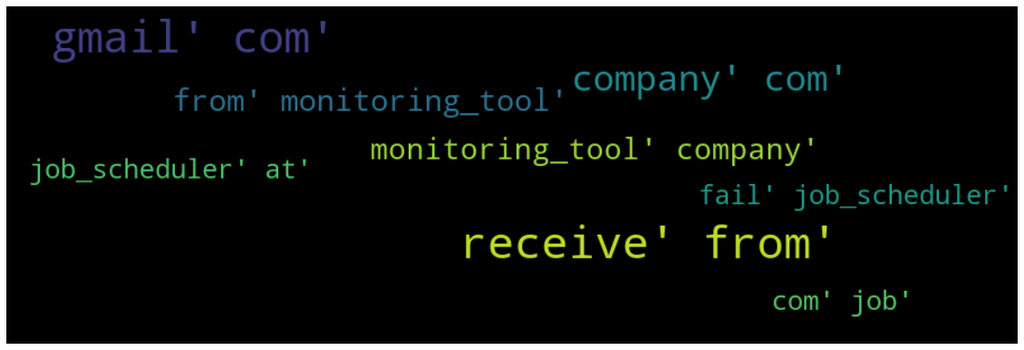

```python
wc = WordCloud(width=900, height=300, max_font_size=40, max_words=100, min_font_size=20).generate(text_words_trigrams_wc)
plt.figure(figsize=(20,10))
plt.imshow(wc, interpolation="bilinear")
plt.axis("off")
plt.margins(x=0, y=0)
plt.show()
```

```python
new_df = data.copy()
```

```python
new_df['words'] = text_words_bigrams
```

```python
new_df.head(2).T
```

|  | 0 | 1 |
| --- | --- | --- |
| Short description | login issue | outlook |
| Description | -verified user details.(employee # & manager n... | receive from : hmjdrvpb.komuaywn@gmail.com hel... |
| Caller | spxjnwir pjlcoqds | hmjdrvpb komuaywn |
| Assignment group | GRP_0 | GRP_0 |
| New_Assignment_Groups | GRP_0 | GRP_0 |
| Text_length | 206 | 194 |
| words | [verified, user, details_employee, manager, na... | [receive, from, hmjdrvpb, komuaywn, gmail, com... |

```python
value = new_df[new_df.columns[4]].value_counts().sort_values(ascending=False).index
value
```

```
Index(['GRP_0', 'GRP_8', 'GRP_24', 'GRP_12', 'GRP_9', 'GRP_2', 'GRP_19',
       'GRP_3', 'GRP_6', 'GRP_13', 'GRP_10', 'GRP_5', 'GRP_14', 'GRP_25',
       'GRP_33', 'GRP_4', 'GRP_29', 'GRP_18', 'GRP_16', 'GRP_31', 'GRP_7',
       'GRP_34', 'GRP_26', 'GRP_40', 'GRP_28', 'GRP_41', 'GRP_30', 'GRP_15',
       'GRP_42', 'GRP_20', 'GRP_45', 'GRP_1', 'GRP_22', 'GRP_11', 'GRP_21',
       'GRP_47', 'GRP_17', 'GRP_23', 'GRP_48', 'GRP_62', 'GRP_27', 'GRP_39',
       'GRP_60', 'GRP_37', 'GRP_44', 'GRP_50', 'GRP_36', 'GRP_65', 'GRP_53',
       'GRP_52', 'GRP_51', 'GRP_55', 'GRP_46', 'GRP_59', 'GRP_49', 'GRP_43',
       'GRP_32', 'GRP_63', 'GRP_66', 'GRP_58', 'GRP_56', 'GRP_68', 'GRP_38',
       'GRP_71', 'GRP_69', 'GRP_54', 'GRP_57', 'GRP_72', 'GRP_61', 'GRP_35',
       'GRP_70', 'GRP_73', 'GRP_64', 'GRP_67'],
      dtype='object')
```

```python
def wordcloud_grp(f, x):
    wordclouds_0=' '.join(map(str, f))
    wc = WordCloud(width=900, height=200, max_font_size=50, min_font_size=30, max_words=50).generate(wordclouds_0)
    plt.figure(figsize=(20,10))
    plt.imshow(wc, interpolation="bilinear")
    plt.axis("off")
    plt.title("Most common 50 words of {}".format(x))
    plt.margins(x=0, y=0)
    plt.show()
```

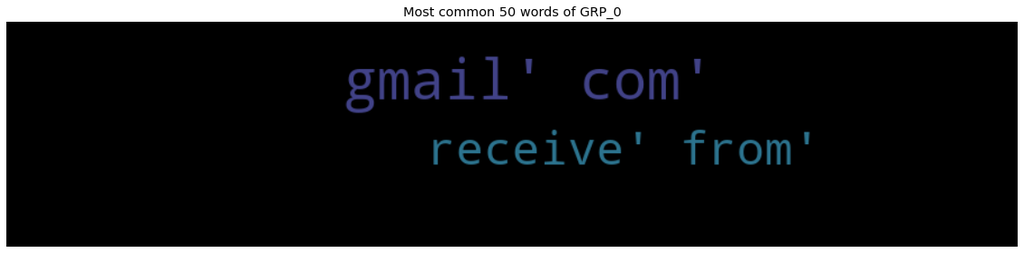

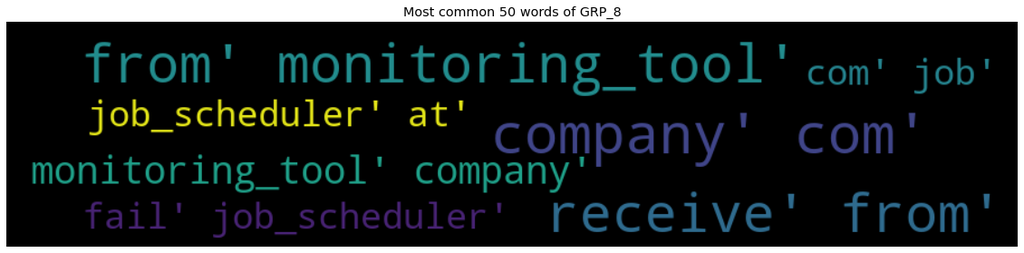

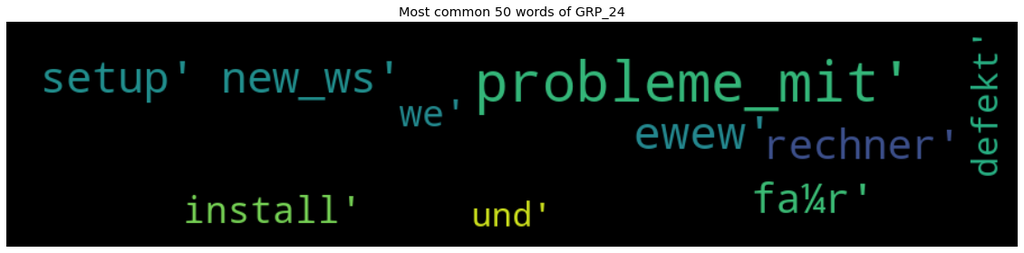

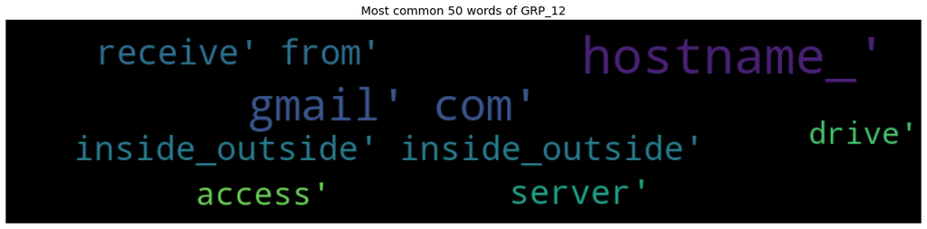

```python
n_a_grps_cld=4  # n_a_grps_cld= new_df[new_df.columns[4]].value_counts().count()
for i in range(n_a_grps_cld):
    Grp = new_df[new_df [new_df.columns[4]] == value[i]]
    Grp = Grp['words']
    wordcloud_grp(Grp,value[i])
```

## N-GRAM [COMMON DATA] & VISUALISATION

```python
def get_corpus(text):
    words = []
    for i in text:
        for j in i.split():
            words.append(j.strip())
    return words
corpus = get_corpus(new_df[new_df.columns[1]])
corpus[:5]
```

```
['-verified', 'user', 'details.(employee', '#', '&']
```

```python
counter = Counter(corpus)
most_common = counter.most_common(10)
most_common = dict(most_common)
most_common
```

```
{'(': 2139,
 ')': 2716,
 ',': 5821,
 '-': 2299,
 '.': 10439,
 ':': 9588,
 '=': 2317,
 '_': 24619,
 'from': 2425,
 'receive': 2429}
```

```python
def get_top_text_ngrams(corpus, n, g):
    vec = CountVectorizer(ngram_range=(g, g)).fit(corpus)
    bag_of_words = vec.transform(corpus)
    sum_words = bag_of_words.sum(axis=0)
    words_freq = [(word, sum_words[0, idx]) for word, idx in vec.vocabulary_.items()]
    words_freq =sorted(words_freq, key = lambda x: x[1], reverse=True)
    return words_freq[:n]
```

```python
most_common_uni = get_top_text_ngrams(new_df[new_df.columns[1]],20,1)
most_common_uni = dict(most_common_uni)
temp = pd.DataFrame(columns = ["Common_words" , 'Count'])
temp["Common_words"] = list(most_common_uni.keys())
temp["Count"] = list(most_common_uni.values())
fig = px.bar(temp, x="Count", y="Common_words", title='Commmon Words in Text', orientation='h',
             width=900, height=500,color='Common_words')
fig.show()
```

[interactive chart not shown]

```python
most_common_bi = get_top_text_ngrams(new_df[new_df.columns[1]],20,2)
most_common_bi = dict(most_common_bi)
temp = pd.DataFrame(columns = ["Common_words" , 'Count'])
temp["Common_words"] = list(most_common_bi.keys())
temp["Count"] = list(most_common_bi.values())
fig = px.bar(temp, x="Count", y="Common_words", title='Commmon Bigrams in Text', orientation='h',
             width=900, height=500,color='Common_words')
fig.show()
```

[interactive chart not shown]

```python
most_common_tri = get_top_text_ngrams(new_df[new_df.columns[1]],20,3)
most_common_tri = dict(most_common_tri)
temp = pd.DataFrame(columns = ["Common_words" , 'Count'])
temp["Common_words"] = list(most_common_tri.keys())
temp["Count"] = list(most_common_tri.values())

fig = px.bar(temp, x="Count", y="Common_words", title='Commmon Trigrams in Text', orientation='h',
             width=900, height=500,color='Common_words')
fig.show()
```

[interactive chart not shown]

Notes:

- Word Cloud & Topic Modeling & N-Grams: We have used word cloud to visualize the frequently existing words and have also performed topic modeling (using Gensim LDA Model) to understand the correlated words in the text across the incident reports i.e. grouping the tickets or incidents based on the words used in the text. We have also tried to plot the number of words used in each of the tickets to study the outliers.
- We used plotly express library to plot this n-grams as visuas. These visuals are interactive display on the python notebook. These plots are shown in the report. If the above code is executed, the same would show up run time (as of now this is showing up as white space) . The same is valid for LDA visualisation for topic modeling below. We have added the graphs in the report.

## LDA MODEL

```python
id2word = corpora.Dictionary(text_words_bigrams)
texts = text_words_bigrams
corpus = [id2word.doc2bow(text) for text in texts]
print(corpus[:1])
print()
print([[(id2word[id], freq) for id, freq in cp] for cp in corpus[:1]])
```

```python
lda_model = LdaModel(corpus=corpus,id2word=id2word,num_topics=7,random_state=200,update_every=1,chunksize=800,passes=10,alpha='auto',per_word_topics=True)
```

```python
pprint(lda_model.print_topics())
doc_lda = lda_model[corpus]
```

```python
texts=text_words_bigrams
print('\nPerplexity: ', lda_model.log_perplexity(corpus))
coherence_model_lda = CoherenceModel(model=lda_model, texts=texts, dictionary=id2word, coherence='c_v')
coherence_lda = coherence_model_lda.get_coherence()
print('\nCoherence Score: ', coherence_lda)
```

[output not shown]

```python
pyLDAvis.enable_notebook()
vis = pyLDAvis.gensim.prepare(lda_model, corpus, id2word)
vis
```

# DATASET GENERATION

## PRE-PROCESSED DATA

```python
data.tail(2).T
```

|  | 7837 | 7838 |
| --- | --- | --- |
| Short description | machine não está funcionando | an mehreren pc`s lassen sich verschiedene prgr... |
| Description | unable access machine utility finish drawer ad... | mehreren pc`s lassen sich verschiedene prgramd... |
| Caller | ufawcgob aowhxjky | kqvbrspl jyzoklfx |
| Assignment group | GRP_62 | GRP_49 |
| New_Assignment_Groups | GRP_62 | GRP_49 |
| Text_length | 103 | 82 |

```python
data.shape,len(data[data.columns[4]].value_counts().sort_values(ascending=False)), len(data[data.columns[3]].value_counts().sort_values(ascending=False)),
```

```
((7839, 6), 74, 74)
```

Important:

- The target class is imbalanced. We have many classes with less than 10 incidents. We have avoided the temptation to group such scantly populated classes in order to balance the input dataset. Instead we planned to use the resampling and SMOTE and class weights to address the target class imbalance. Our earlier plan was to build three different dataset. First to have GRP_0 and rest of the records classified into one and use two step classification model and the second one to have non-GRP_0 groups resampled for the second order classification and third dataset in which we keep all the groups (74) as it is and address the imbalance issue.
- After due considerations and discussions, we finally decided to pursue only the third dataset so that we don’t tend to force fit the data into model. In future, these group names could be changed any time and fulcrum of imbalance could shift to some other group. In such a situation, this hard coded approach as followed in case of the first two datasets, we fail to deliver the right classification. It could fail miserably. However, all the data related views are presented below. However we kept and preserved all the three datasets for any future references. We have marked the first two datasets as "Dropped" in the heading below. This peice of code is execuded for all practical purpose and retained for any future reference only.

## DATASET 1 [DATA DIVIDED INTO TWO GROUPS - GRP_0 AND N_GRP_0][DROPPED]

```python
data_1 = data.copy()
```

```python
len(data_1[data_1.columns[4]].value_counts().sort_values(ascending=False))
```

```
74
```

```python
data_1.head(2).T
```

```python
data_1.shape
```

```python
data_1[data_1.columns[4]]=data_1[data_1.columns[4]].apply(lambda x : 'N_GRP_0' if x != 'GRP_0'  else x)
data_1.tail(2).T
```

```python
data_1.shape, len(data_1[data_1.columns[4]].value_counts().sort_values(ascending=False))
```

```python
len(data_1[data_1.columns[4]].value_counts().sort_values(ascending=False)), data_1[data_1.columns[4]].value_counts().sort_values(ascending=False)
```

```python
order = data_1[data_1.columns[4]].value_counts().sort_values(ascending=False).index
plt.subplots(figsize=(5,5))
sns.countplot(x=data_1.columns[4], data=data_1, color='royalblue', order=order)
```

```python
data_1.groupby(data_1.columns[4])[data_1.columns[5]].agg(lambda x: sum(x)).plot(kind='pie',title='Total Text Corpus By Assignment Groups')
```

```python
#data_1[data_1[data_1.columns[4]]== 'N_GRP_0'    ][data_1.columns[1]].str.len().min()
```

```python
fig,(ax1,ax2)=plt.subplots(1,2,figsize=(12,8))

text_length=data_1[data_1[data_1.columns[4]]== 'N_GRP_0'    ][data_1.columns[1]].str.len()
ax1.hist(text_length,color='red')
ax1.set_title('Text within N_GRP_0')

text_length=data_1[data_1[data_1.columns[4]]== 'GRP_0'    ][data_1.columns[1]].str.len()
ax2.hist(text_length,color='green')
ax2.set_title('Text within GRP_0')

fig.suptitle('Characters in texts')
plt.show()
```

```python
fig,(ax1,ax2)=plt.subplots(1,2,figsize=(12,8))

text_length=data_1[data_1[data_1.columns[4]]== 'N_GRP_0'    ][data_1.columns[1]].str.split().map(lambda x: len(x))
ax1.hist(text_length,color='red')
ax1.set_title('Text within N_GRP_0')

text_length=data_1[data_1[data_1.columns[4]]== 'GRP_0'    ][data_1.columns[1]].str.split().map(lambda x: len(x))
ax2.hist(text_length,color='green')
ax2.set_title('Text within GRP_0')

fig.suptitle('Words in texts')
plt.show()
```

```python
wc = WordCloud(max_words = 100 , width = 900 , height = 300).generate(" ".join(data_1[ data_1[data_1.columns[4]]  == 'N_GRP_0' ][data_1.columns[1]]))
plt.figure(figsize=(20,10))
plt.imshow(wc, interpolation="bilinear")
plt.axis("off")
plt.margins(x=0, y=0)
plt.show()
```

```python
wc = WordCloud(max_words = 100 , width = 900 , height = 300).generate(" ".join(data_1[ data_1[data_1.columns[4]]  == 'GRP_0' ][data_1.columns[1]]))
plt.figure(figsize=(20,10))
plt.imshow(wc, interpolation="bilinear")
plt.axis("off")
plt.margins(x=0, y=0)
plt.show()
```

```python
data_1.shape, len(data_1[data_1.columns[4]].value_counts().sort_values(ascending=False)),data_1[data_1.columns[4]].value_counts().sort_values(ascending=False)
```

```python
data_1.head(3).T
```

## DATASET 2 [GROUPS OTHER THAN GRP_0 + RESAMPLED FOR IMBALANCE][DROPPED]

```python
data.head(3).T
```

```python
print(data.columns[4])
```

```python
data_2 = data[ data[data.columns[4]] != 'GRP_0' ]
data_2.shape, len( data_2[data_2.columns[4]].unique()), data_2[data_2.columns[4]].unique()
```

```python
order = data_2[data_2.columns[4]].value_counts().sort_values(ascending=False).index
```

```python
plt.subplots(figsize=(20,5))
ax=sns.countplot(x=data_2.columns[4], data=data_2, color='royalblue',order=order)
ax.set_xticklabels(ax.get_xticklabels(), rotation=90, ha="right")
plt.show()
```

```python
data_2_max = data_2[data_2.columns[4]].value_counts().max()
data_2_max
```

```python
data_2_resampled = data_2[0:0]
data_2_resampled.shape
```

```python
data_2_resampled.head().T
```

```python
data_2_resampled.shape, data_2.shape , len(data_2[data_2.columns[4]].unique()), data_2_max, data_2_max/2
```

```python
for i in data_2[data_2.columns[4]].unique():
    data_2_resampled= data_2_resampled.append(resample(data_2[data_2[data_2.columns[4]] == i],
                                                     replace=True,
                                                     n_samples=int(data_2_max/2),
                                                     random_state=1)
                                           )
```

```python
data_2_resampled.shape, type(data_2_resampled)
```

```python
data_2_resampled.reset_index(inplace=True, drop=True)
```

```python
data_2_resampled.head(2).T
```

```python
data_1.shape, data_2.shape, data_2_resampled.shape #otherGrpsResampled.shape
```

```python
plt.subplots(figsize=(19,3))
ax=sns.countplot(x=data_2_resampled.columns[4], data=data_2_resampled, color='royalblue',
                 order=data_2_resampled[data_2_resampled.columns[4]].value_counts().sort_values(ascending=False).index)
ax.set_xticklabels(ax.get_xticklabels(), rotation=90, ha="right")
ax.set_title('Number of Incident Frequency By New Assignment Groups - Non GRP_0 Class and Resampled')
plt.show()
```

```python
data_2_resampled[data_2_resampled.columns[4]].value_counts()[:5] #data_2_resampled[data_2_resampled.columns[4]].value_counts()
```

## DATASET 3 [BASE DATASET RESAMPLED FOR CLASS IMBALANCE][SELECTED]

```python
data.shape
```

```
(7839, 6)
```

```python
data_3_resampled = data[0:0]
data_3_resampled.shape
```

```
(0, 6)
```

```python
data_3_resampled.head().T
```

| Short description |
| --- |
| Description |
| Caller |
| Assignment group |
| New_Assignment_Groups |
| Text_length |

```python
print(data.columns[4])
len(data[data.columns[4]].unique())
```

```
New_Assignment_Groups
```

```
74
```

```python
min_t_cnt= 'GRP_0'
mask_1= data[data.columns[4]] != min_t_cnt #mask_1 for less than or same as min text length
mask_2= data[data.columns[4]] == min_t_cnt #mask_2 for above min text length
data.shape[0],len(data[mask_1]), len(data[mask_2])
```

```
(7839, 4429, 3410)
```

```python
data_3_max = data[mask_1][data[mask_1].columns[4]].value_counts().max()
data_3_max
```

```
645
```

Note:

- Resampling the data as target class is highly imbalanced as mentioned earlier.
- We will also expore other options of managing the class balance in next iteration.

```python
for i in data[data.columns[4]].unique():
    data_3_resampled = data_3_resampled.append(resample(data[data[data.columns[4]] == i],
                                                        replace=True,
                                                        n_samples=int(data_3_max),
                                                        random_state=1
                                                       )
                                              )
```

```python
data_3_resampled.shape, len(data_3_resampled[data_3_resampled.columns[4]].unique())
```

```
((47730, 6), 74)
```

```python
order = data_3_resampled[data_3_resampled.columns[4]].value_counts().sort_values(ascending=False).index
order, len(order)
```

```
(Index(['GRP_49', 'GRP_22', 'GRP_33', 'GRP_32', 'GRP_58', 'GRP_41', 'GRP_35',
        'GRP_0', 'GRP_16', 'GRP_19', 'GRP_5', 'GRP_59', 'GRP_54', 'GRP_31',
        'GRP_48', 'GRP_69', 'GRP_13', 'GRP_25', 'GRP_36', 'GRP_37', 'GRP_53',
        'GRP_70', 'GRP_6', 'GRP_11', 'GRP_23', 'GRP_34', 'GRP_43', 'GRP_30',
        'GRP_67', 'GRP_51', 'GRP_9', 'GRP_7', 'GRP_24', 'GRP_56', 'GRP_50',
        'GRP_68', 'GRP_57', 'GRP_44', 'GRP_55', 'GRP_52', 'GRP_21', 'GRP_64',
        'GRP_71', 'GRP_73', 'GRP_46', 'GRP_38', 'GRP_47', 'GRP_40', 'GRP_18',
        'GRP_26', 'GRP_60', 'GRP_2', 'GRP_10', 'GRP_39', 'GRP_12', 'GRP_42',
        'GRP_29', 'GRP_28', 'GRP_3', 'GRP_27', 'GRP_65', 'GRP_1', 'GRP_20',
        'GRP_66', 'GRP_8', 'GRP_72', 'GRP_17', 'GRP_62', 'GRP_15', 'GRP_63',
        'GRP_4', 'GRP_14', 'GRP_45', 'GRP_61'],
       dtype='object'), 74)
```

```python
 #data_3_resampled[data_3_resampled.columns[4]].value_counts()
```

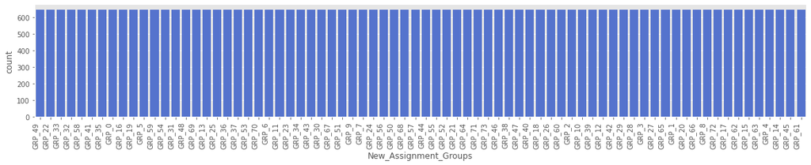

```python
plt.subplots(figsize=(20,3))
ax=sns.countplot(x=data_3_resampled.columns[4], data=data_3_resampled, color='royalblue' , order=order)
ax.set_xticklabels(ax.get_xticklabels(), rotation=90, ha="right")
plt.show()
```

Note: As seen from above, all classes are balanced now with resampling. Since GRP_0 was having the highly skewed or execessive number of incident records. We have considered the next highest number of incidents in the assignment group as a basis to resvolve the imbalance issue. This makes the incident free of bias for classification purpose.

## LABEL/TARGET CLASS ENCODING FOR DATASETS 1,2,3

```python
def labelencoder(dataframe) :
    label_encoder = preprocessing.LabelEncoder()
    dataframe = label_encoder.fit_transform(dataframe)
    encodedlabels = dict(zip(label_encoder.transform(label_encoder.classes_), label_encoder.classes_))
    return dataframe, encodedlabels
```

```python
"""
Since we plan to use only the third data set, we have not generated the dataset 1 and 2 and hence label encoding will be restricted to dataset 3
data_1.columns[4], data_1.shape, data_2_resampled.columns[4], data_2_resampled.shape, data_3_resampled.columns[4], data_3_resampled.shape
"""

data_3_resampled.columns[4], data_3_resampled.shape
```

```
('New_Assignment_Groups', (47730, 6))
```

```python
"""
Since we plan to use only the third data set, we have not generated the dataset 1 and 2 and hence label encoding will be restricted to dataset 3
data_1[data_1.columns[4]], data_1_encoded_labels = labelencoder(data_1[data_1.columns[4]])
data_2_resampled[data_2_resampled.columns[4]], data_2_resampled_encoded_labels = labelencoder(data_2_resampled[data_2_resampled.columns[4]])
data_3_resampled[data_3_resampled.columns[4]], data_3_resampled_labels = labelencoder(data_3_resampled[data_3_resampled.columns[4]])
"""

data_3_resampled[data_3_resampled.columns[4]], data_3_resampled_labels = labelencoder(data_3_resampled[data_3_resampled.columns[4]])
```

```python
"""
Since we plan to use only the third data set, we have not generated the dataset 1 and 2 and hence label encoding will be restricted to dataset 3
data_1.head(2).T
data_2_resampled.head(2).T
data_3_resampled.head(2).T
"""
data_3_resampled.head(2).T
```

|  | 2316 | 407 |
| --- | --- | --- |
| Short description | collaboration_platform site is not opening | account locked. |
| Description | collaboration_platform site opening | account lock . |
| Caller | anpocezt qturbxsg | bkyphsgq cfyksehu |
| Assignment group | GRP_0 | GRP_0 |
| New_Assignment_Groups | 0 | 0 |
| Text_length | 42 | 15 |

# MODEL BUILDING

## WORD EMBEDDING [WORD2VEC] [DATASET 3]

```python
data_3_resampled.head(2).T
```

|  | 2316 | 407 |
| --- | --- | --- |
| Short description | collaboration_platform site is not opening | account locked. |
| Description | collaboration_platform site opening | account lock . |
| Caller | anpocezt qturbxsg | bkyphsgq cfyksehu |
| Assignment group | GRP_0 | GRP_0 |
| New_Assignment_Groups | 0 | 0 |
| Text_length | 42 | 15 |

```python
data_3_resampled.shape, data_3_resampled.columns[1]
```

```
((47730, 6), 'Description')
```

```python
sentences = [i.split(' ') for i in data_3_resampled[ data_3_resampled.columns[1] ] ]
min_word_count = 2
start = time.time()
word2vec = Word2Vec( sentences = sentences, min_count = min_word_count)
time.sleep(1)
end = time.time()
print(f"Time Taken To Generate Word Embedding : {end - start}")
```

```
Time Taken To Generate Word Embedding : 11.180785417556763
```

```python
word2vec.wv.save_word2vec_format(project_path+ 'word2vec_vector.txt')
```

```python
print(len(sentences))
embeddings_index = dict()
f = open(project_path+'word2vec_vector.txt', encoding="utf8")
for i in f:
    values = i.split()
    word = values[0]
    coefs = np.asarray(values[1:], dtype='float32')
    embeddings_index[word] = coefs
f.close()
print('Loaded %s word vectors.' % len(embeddings_index))
```

```
47730
Loaded 16599 word vectors.
```

## WORD EMBEDDING [GloVe] [DATASET 3]

Note: Word Embedding & Vectorization: We plan to use Word2Vec and Glove Embedding for vectorization and preparation of dataset. We will be use this embedding to check how LSTM responds to the performance. The differences are captured for to be analyzed at the end of the project.

```python
EMBEDDING_FILE = 'glove.twitter.27B.200d.txt'
```

```python
embeddings_glove = {}
for o in open(project_path+EMBEDDING_FILE, encoding="utf8"):
    word = o.split(" ")[0]
    #print(word)
    embd = o.split(" ")[1:]
    embd = np.asarray(embd, dtype='float32')
    #print(embd)
    embeddings_glove[word] = embd
```

```python
print("Dimension of the embedding vector is {}".format(len(embeddings_glove["ticket"])))
print("Dimension of the embedding vector is {}".format(len(embeddings_glove["password"])))
```

```
Dimension of the embedding vector is 200
Dimension of the embedding vector is 200
```

```python
embeddings_dict = {}
```

```python
with open(project_path+EMBEDDING_FILE, 'r', encoding="utf-8") as f:
    for line in f:
        values = line.split()
        word = values[0]
        vector = np.asarray(values[1:], "float32")
        embeddings_dict[word] = vector
```

```python
tsne = TSNE(n_components=2, random_state=0)
```

```python
words =  list(embeddings_dict.keys())
vectors = [embeddings_dict[word] for word in words]
```

```python
Y = tsne.fit_transform(vectors[:1000])
```

### Word Embedding

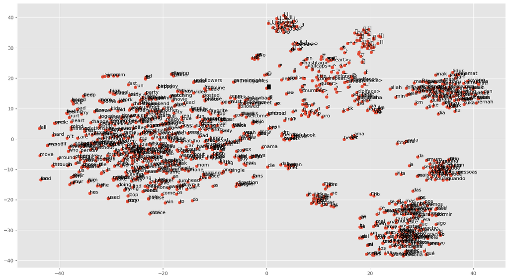

```python
plt.figure(figsize=(18, 10), dpi=80)
plt.scatter(Y[:, 0], Y[:, 1])

for label, x, y in zip(words, Y[:, 0], Y[:, 1]):
    plt.annotate(label, xy=(x, y), xytext=(0, 0), textcoords="offset points")

plt.show()
```

Note:

- We planned to use both Deep Learning and Machine Learning models for classifying the incidents by assignment groups with the existing and same dataset after suitable cleaning and vectorization.:
- Deep Learning : Bidirectional LSTM - With Word2Vec and Glove Embedding, GRU, RNN, BERT
- Machine Learning Models: Random Forest Classifier – With and Without Class Weight, Support Vector Machine, Naïve Bayes, Adaboost, Bagging, GradientBoost, KNN

## LSTM, GRU, RNN MODELS

```python
#data_1.shape, data_1.columns[4], data_2_resampled.shape, data_2_resampled.columns[4], data_3_resampled.shape, data_3_resampled.columns[4]
#data_1.shape, data_1.columns[1], data_2_resampled.shape, data_2_resampled.columns[1], data_3_resampled.shape, data_3_resampled.columns[1]
```

```python
class LSTM_Model:
    model= Model()
    X_test=[]
    y_test=[]
    embedding_matrix=[]

    def wordTokenizer(self, dataframe):
        tokenizer = Tokenizer(num_words=numWords,filters='!"#$%&()*+,-./:;<=>?@[\\]^_`{|}~\t\n',lower=True,split=' ', char_level=False)
        tokenizer.fit_on_texts(dataframe)
        dataframe = tokenizer.texts_to_sequences(dataframe)
        return tokenizer,dataframe

    def splitData(self,X,y):
        print("Number of Samples:", len(X))
        print("Number of Labels: ", len(y))
        X_train, self.X_test, y_train, self.y_test = train_test_split(X, y, test_size=0.2, random_state=10)
        X_train, X_Val, y_train, y_Val = train_test_split(X, y, test_size=0.2, random_state=10)
        print("Number of train Samples:", len(X_train))
        print("Number of val Samples:", len(X_Val))
        return X_train, self.X_test, y_train, self.y_test, X_Val, y_Val

    def tokenizeAndEmbedding(self,dataframe):
        tokenizer, X = self.wordTokenizer(dataframe[dataframe.columns[1]]) #Description column is the Feature Data
        y = np.asarray(dataframe[dataframe.columns[4]]) #New_Assignment_Groups column as Y  or Target is an encoded column
        X = pad_sequences(X, maxlen = maxlen)
        self.embedding_matrix = np.zeros((numWords+1, 100))
        for i,word in tokenizer.index_word.items():
            if i<numWords+1:
                embedding_vector = embeddings_index.get(word)
                if embedding_vector is not None:
                    self.embedding_matrix[i] = embedding_vector
        return X,y

    def train(self, dataframe, batch_size, epochs):
        X,y = self.tokenizeAndEmbedding(dataframe)
        X_train, _, y_train, _, X_Val, y_Val = self.splitData(X,y)
        model_history = self.fitModel(X_train,y_train,X_Val,y_Val,batch_size, epochs)
        return model_history

    def fitModel(self,X_train,y_train,X_Val,y_Val,batch_size, epochs):
        input_layer = Input(shape=(maxlen,),dtype=tf.int64)
        embed = Embedding(numWords+1,output_dim=100,input_length=maxlen,weights=[self.embedding_matrix], trainable=True)(input_layer)
        lstm=Bidirectional(LSTM(128))(embed)
        drop=Dropout(0.3)(lstm)
        dense = Dense(100,activation='relu')(drop)
        out=Dense(len((pd.Series(y_train)).unique()),activation='softmax')(dense)
        self.model = Model(input_layer,out)
        self.model.compile(loss='sparse_categorical_crossentropy',optimizer="adam",metrics=['accuracy'])
        self.model.summary()
        plot_model(self.model,to_file="LSTM_Model.jpg", show_shapes=True, show_layer_names=True)

        checkpoint = ModelCheckpoint('model-{epoch:03d}-{val_accuracy:03f}.h5', verbose=1,
                                     monitor='val_accuracy',
                                     save_best_only=True,
                                     mode='auto')

        reduceLoss = ReduceLROnPlateau(monitor='val_loss', factor=0.2,patience=2, min_lr=0.0001)

        model_history = self.model.fit(X_train,y_train,
                                       batch_size=batch_size,
                                       epochs=epochs,
                                       callbacks=[checkpoint,reduceLoss],
                                       validation_data=(X_Val,y_Val))

        return model_history,self.model

    def prediction(self):
        pred = self.model.predict(self.X_test)
        pred = [i.argmax() for i in pred]
        accuracy = metrics.accuracy_score(self.y_test, pred)
        print("Accuracy of the model :",metrics.accuracy_score(self.y_test, pred))
        return accuracy

    def plotModelAccuracy(self, history, modelname):
        plt.plot(history.history['accuracy'])
        plt.plot(history.history['val_accuracy'])
        plt.title(modelname+' model accuracy')
        plt.ylabel('accuracy')
        plt.xlabel('epoch')
        plt.legend(['train','test'], loc='upper left')
        plt.show()

        plt.plot(history.history['loss'])
        plt.plot(history.history['val_loss'])

        plt.title(modelname+' model loss')
        plt.ylabel('loss')
        plt.xlabel('epoch')
        plt.legend(['train','test'], loc='upper left')
        plt.show()
```

```python
def captureData(dataframe,modelHistory,modelName,descriptions,index_df,resetData):
    if resetData == 1:
        tempResultsDf=pd.DataFrame()
        dataframe=pd.DataFrame()
    else:
        index, acc_value = max(enumerate(modelHistory.history['val_accuracy']), key=operator.itemgetter(1))
        tempResultsDf= pd.DataFrame(
            {'model':[modelName],
             'val_accuracy': [acc_value],
             'val_loss':[modelHistory.history['val_loss'][index]],
             'loss':[modelHistory.history['loss'][index]],
             'accuracy':[modelHistory.history['accuracy'][index]],
             'descriptions':[descriptions]},index={str(index_df)})
        dataframe = pd.concat([dataframe,tempResultsDf])
        dataframe = dataframe[['model','val_accuracy' ,'val_loss','loss','accuracy','descriptions']]
    return dataframe
```

```python
def capturePrediction(dataframe,modelName,descriptions,index_df,pred_accuracy,resetData):
    if resetData == 1:
        tempResultsDf=pd.DataFrame()
        dataframe=pd.DataFrame()
    else:
        tempResultsDf= pd.DataFrame(
            {'model':[modelName],
             'Pred_Accuracy' : [pred_accuracy],
             'descriptions':[descriptions]},index={str(index_df)})
        dataframe = pd.concat([dataframe,tempResultsDf])
        dataframe = dataframe[['model','Pred_Accuracy','descriptions']]
    return dataframe
```

```python
class LSTM_Model_GloVe:
    model= Model()
    X_test=[]
    y_test=[]
    embedding_matrix=[]

    def wordTokenizer(self, dataframe):
        tokenizer = Tokenizer(num_words=numWords,filters='!"#$%&()*+,-./:;<=>?@[\\]^_`{|}~\t\n',lower=True,split=' ', char_level=False)
        tokenizer.fit_on_texts(dataframe)
        dataframe = tokenizer.texts_to_sequences(dataframe)
        return tokenizer,dataframe

    def splitData(self,X,y):
        print("Number of Samples:", len(X))
        print("Number of Labels: ", len(y))
        X_train, self.X_test, y_train, self.y_test = train_test_split(X, y, test_size=0.2, random_state=10)
        X_train, X_Val, y_train, y_Val = train_test_split(X_train, y_train, test_size=0.2, random_state=10)
        print("Number of train Samples:", len(X_train))
        print("Number of val Samples:", len(X_Val))
        return X_train, self.X_test, y_train, self.y_test, X_Val, y_Val

    def tokenizeAndEmbedding(self,dataframe):
        tokenizer, X = self.wordTokenizer(dataframe[dataframe.columns[1]]) #Description column is the Feature Data
        y = np.asarray(dataframe[dataframe.columns[4]]) #New_Assignment_Groups column as Y  or Target is an encoded column
        X = pad_sequences(X, maxlen = maxlen)
        self.embedding_matrix = np.zeros((numWords+1, 200)) # change it to 200 as the glove embedding dimension is of size 200
        for i,word in tokenizer.index_word.items():
            if i<numWords+1:
                embedding_vector = embeddings_glove.get(word) # embeddings_index.get(word)
                if embedding_vector is not None:
                    self.embedding_matrix[i] = embedding_vector
        return X,y

    def train(self, dataframe, batch_size, epochs):
        X,y = self.tokenizeAndEmbedding(dataframe)
        X_train, _, y_train, _, X_Val, y_Val = self.splitData(X,y)
        model_history = self.fitModel(X_train,y_train,X_Val,y_Val,batch_size, epochs)
        return model_history

    def fitModel(self,X_train,y_train,X_Val,y_Val,batch_size, epochs):
        input_layer = Input(shape=(maxlen,),dtype=tf.int64)
        embed = Embedding(numWords+1,output_dim=200,input_length=maxlen,weights=[self.embedding_matrix], trainable=True)(input_layer)  # Change the dimension to 200 as the embed size is 200
        lstm=Bidirectional(LSTM(128))(embed)
        drop=Dropout(0.3)(lstm)
        dense = Dense(100,activation='relu')(drop)
        out=Dense(len((pd.Series(y_train)).unique()),activation='softmax')(dense)
        self.model = Model(input_layer,out)
        self.model.compile(loss='sparse_categorical_crossentropy',optimizer="adam",metrics=['accuracy'])
        self.model.summary()
        plot_model(self.model,to_file="LSTM_Model.jpg", show_shapes=True, show_layer_names=True)

        checkpoint = ModelCheckpoint('model-{epoch:03d}-{val_accuracy:03f}.h5', verbose=1,
                                     monitor='val_accuracy',
                                     save_best_only=True,
                                     mode='auto')

        reduceLoss = ReduceLROnPlateau(monitor='val_loss', factor=0.2,patience=2, min_lr=0.0001)

        model_history = self.model.fit(X_train,y_train,
                                       batch_size=batch_size,
                                       epochs=epochs,
                                       callbacks=[checkpoint,reduceLoss],
                                       validation_data=(X_Val,y_Val))

        return model_history,self.model

    def prediction(self):
        pred = self.model.predict(self.X_test)
        pred = [i.argmax() for i in pred]
        accuracy = metrics.accuracy_score(self.y_test, pred)
        print("Accuracy of the model :",metrics.accuracy_score(self.y_test, pred))
        return accuracy

    def plotModelAccuracy(self, history, modelname):
        plt.plot(history.history['accuracy'])
        plt.plot(history.history['val_accuracy'])
        plt.title(modelname+' model accuracy')
        plt.ylabel('accuracy')
        plt.xlabel('epoch')
        plt.legend(['train','test'], loc='upper left')
        plt.show()

        plt.plot(history.history['loss'])
        plt.plot(history.history['val_loss'])

        plt.title(modelname+' model loss')
        plt.ylabel('loss')
        plt.xlabel('epoch')
        plt.legend(['train','test'], loc='upper left')
        plt.show()
```

```python
class LSTM_Model_GloVe_GRU:
    model= Model()
    X_test=[]
    y_test=[]
    embedding_matrix=[]

    def wordTokenizer(self, dataframe):
        tokenizer = Tokenizer(num_words=numWords,filters='!"#$%&()*+,-./:;<=>?@[\\]^_`{|}~\t\n',lower=True,split=' ', char_level=False)
        tokenizer.fit_on_texts(dataframe)
        dataframe = tokenizer.texts_to_sequences(dataframe)
        return tokenizer,dataframe

    def splitData(self,X,y):
        print("Number of Samples:", len(X))
        print("Number of Labels: ", len(y))
        X_train, self.X_test, y_train, self.y_test = train_test_split(X, y, test_size=0.2, random_state=10)
        X_train, X_Val, y_train, y_Val = train_test_split(X_train, y_train, test_size=0.2, random_state=10)
        print("Number of train Samples:", len(X_train))
        print("Number of val Samples:", len(X_Val))
        return X_train, self.X_test, y_train, self.y_test, X_Val, y_Val

    def tokenizeAndEmbedding(self,dataframe):
        tokenizer, X = self.wordTokenizer(dataframe[dataframe.columns[1]]) #Description column is the Feature Data
        y = np.asarray(dataframe[dataframe.columns[4]]) #New_Assignment_Groups column as Y  or Target is an encoded column
        X = pad_sequences(X, maxlen = maxlen)
        self.embedding_matrix = np.zeros((numWords+1, 200)) # change it to 200 as the glove embedding dimension is of size 200
        for i,word in tokenizer.index_word.items():
            if i<numWords+1:
                embedding_vector = embeddings_glove.get(word) # embeddings_index.get(word)
                if embedding_vector is not None:
                    self.embedding_matrix[i] = embedding_vector
        return X,y

    def train(self, dataframe, batch_size, epochs):
        X,y = self.tokenizeAndEmbedding(dataframe)
        X_train, _, y_train, _, X_Val, y_Val = self.splitData(X,y)
        model_history = self.fitModel(X_train,y_train,X_Val,y_Val,batch_size, epochs)
        return model_history

    def fitModel(self,X_train,y_train,X_Val,y_Val,batch_size, epochs):
        input_layer = Input(shape=(maxlen,),dtype=tf.int64)
        embed = Embedding(numWords+1,output_dim=200,input_length=maxlen,weights=[self.embedding_matrix], trainable=True)(input_layer)  # Change the dimension to 200 as the embed size is 200
        gru=GRU(128)(embed)
        drop=Dropout(0.3)(gru)
        dense = Dense(100,activation='relu')(drop)
        out=Dense(len((pd.Series(y_train)).unique()),activation='softmax')(dense)
        self.model = Model(input_layer,out)
        self.model.compile(loss='sparse_categorical_crossentropy',optimizer="adam",metrics=['accuracy'])
        self.model.summary()
        plot_model(self.model,to_file="LSTM_Model.jpg", show_shapes=True, show_layer_names=True)

        checkpoint = ModelCheckpoint('model-{epoch:03d}-{val_accuracy:03f}.h5', verbose=1,
                                     monitor='val_accuracy',
                                     save_best_only=True,
                                     mode='auto')

        reduceLoss = ReduceLROnPlateau(monitor='val_loss', factor=0.2,patience=2, min_lr=0.0001)

        model_history = self.model.fit(X_train,y_train,
                                       batch_size=batch_size,
                                       epochs=epochs,
                                       callbacks=[checkpoint,reduceLoss],
                                       validation_data=(X_Val,y_Val))

        return model_history,self.model

    def prediction(self):
        pred = self.model.predict(self.X_test)
        pred = [i.argmax() for i in pred]
        accuracy = metrics.accuracy_score(self.y_test, pred)
        print("Accuracy of the model :",metrics.accuracy_score(self.y_test, pred))
        return accuracy

    def plotModelAccuracy(self, history, modelname):
        plt.plot(history.history['accuracy'])
        plt.plot(history.history['val_accuracy'])
        plt.title(modelname+' model accuracy')
        plt.ylabel('accuracy')
        plt.xlabel('epoch')
        plt.legend(['train','test'], loc='upper left')
        plt.show()

        plt.plot(history.history['loss'])
        plt.plot(history.history['val_loss'])

        plt.title(modelname+' model loss')
        plt.ylabel('loss')
        plt.xlabel('epoch')
        plt.legend(['train','test'], loc='upper left')
        plt.show()
```

```python
class RNN_Model_GloVe:
    X_test=[]
    y_test=[]
    embedding_matrix=[]

    def wordTokenizer(self, dataframe):
        tokenizer = Tokenizer(num_words=numWords,filters='!"#$%&()*+,-./:;<=>?@[\\]^_`{|}~\t\n',lower=True,split=' ', char_level=False)
        tokenizer.fit_on_texts(dataframe)
        dataframe = tokenizer.texts_to_sequences(dataframe)
        return tokenizer,dataframe

    def splitData(self,X,y):
        print("Number of Samples:", len(X))
        print("Number of Labels: ", len(y))
        X_train, self.X_test, y_train, self.y_test = train_test_split(X, y, test_size=0.2, random_state=10)
        X_train, X_Val, y_train, y_Val = train_test_split(X, y, test_size=0.2, random_state=10)
        print("Number of train Samples:", len(X_train))
        print("Number of val Samples:", len(X_Val))
        return X_train, self.X_test, y_train, self.y_test, X_Val, y_Val

    def tokenizeAndEmbedding(self,dataframe):
        tokenizer, X = self.wordTokenizer(dataframe[dataframe.columns[1]]) #Description column is the Feature Data
        y = np.asarray(dataframe[dataframe.columns[4]]) #New_Assignment_Groups column as Y  or Target is an encoded column
        X = pad_sequences(X, maxlen = maxlen)
        self.embedding_matrix = np.zeros((numWords+1, 200)) # change it to 200 as the glove embedding dimension is of size 200
        for i,word in tokenizer.index_word.items():
            if i<numWords+1:
                embedding_vector = embeddings_glove.get(word) # embeddings_index.get(word)
                if embedding_vector is not None:
                    self.embedding_matrix[i] = embedding_vector
        return X,y

    def train(self, dataframe, batch_size, epochs):
        X,y = self.tokenizeAndEmbedding(dataframe)
        X_train, _, y_train, _, X_Val, y_Val = self.splitData(X,y)

        embed = Embedding(numWords+1,output_dim=200,input_length=maxlen,weights=[self.embedding_matrix], trainable=True)
        model=Sequential()
        model.add(Input(shape=(maxlen,),dtype=tf.int64))
        model.add(embed)
        model.add(Conv1D(100,10,activation='relu'))
        model.add(MaxPooling1D(pool_size=2))
        model.add(Dropout(0.3))
        model.add(Conv1D(100,10,activation='relu'))
        model.add(MaxPooling1D(pool_size=2))
        model.add(Bidirectional(LSTM(128)))
        model.add(Dropout(0.3))
        model.add(Dense(100,activation='relu'))
        model.add(Dense(len((pd.Series(y_train)).unique()),activation='softmax'))
        model.compile(loss='sparse_categorical_crossentropy',optimizer="adam",metrics=['accuracy'])

        model.summary()
        plot_model(model,to_file="RNN_Model_GloVe.jpg")

        checkpoint = ModelCheckpoint('model-{epoch:03d}-{val_accuracy:03f}.h5', verbose=1, monitor='val_accuracy',save_best_only=True, mode='auto')
        reduceLoss = ReduceLROnPlateau(monitor='val_loss', factor=0.2,patience=2, min_lr=0.0001)
        model_history = model.fit(X_train,y_train,batch_size=batch_size, epochs=epochs, callbacks=[checkpoint,reduceLoss], validation_data=(X_Val, y_Val))
        return model_history, model

    def prediction(self, model): # def prediction(self):
        pred = model.predict(self.X_test) #self.model.predict(self.X_test)
        pred = [i.argmax() for i in pred]
        accuracy = metrics.accuracy_score(self.y_test, pred)
        print("Accuracy of the model :", metrics.accuracy_score(self.y_test, pred))
        return accuracy

    def plotModelAccuracy(self, history, modelname):
        plt.plot(history.history['accuracy'])
        plt.plot(history.history['val_accuracy'])
        plt.title(modelname+' model accuracy')
        plt.ylabel('accuracy')
        plt.xlabel('epoch')
        plt.legend(['train','test'], loc='upper left')
        plt.show()

        plt.plot(history.history['loss'])
        plt.plot(history.history['val_loss'])

        plt.title(modelname+' model loss')
        plt.ylabel('loss')
        plt.xlabel('epoch')
        plt.legend(['train','test'], loc='upper left')
        plt.show()
```

# DL MODEL 1: LSTM [WORD2VEC] [DATASET 3]

LSTM stands for “long short-term memory” and it’s a type of recurrent unit that has become very popular in recent years due to its superior performance and the fact that it doesn’t as easily succumb to the vanishing gradient problem. Bi-Directional LSTM are a variant of traditional LSTM but improve the model performance by using the training inputs (texts/words) in a sequence (sentence) first as a normal sentence and then reading the tokens in the sentence in a reverse order. In short, for every token, in the sentence, there is a data about the tokens ahead as well as behind it with a memory parameters as defined in the model. This improves the effectiveness of the classification.

```python
data_3_resampled.head(2).T
```

|  | 0 | 1 |
| --- | --- | --- |
| Short description | collaboration_platform site is not opening | account locked. |
| Description | collaboration_platform site opening | account lock . |
| Caller | anpocezt qturbxsg | bkyphsgq cfyksehu |
| Assignment group | GRP_0 | GRP_0 |
| New_Assignment_Groups | 0 | 0 |
| Text_length | 42 | 15 |

```python
#data_1.shape, data_1.columns[4] , data_1.shape, data_1.columns[1], len(data_1[data_1.columns[4]].value_counts().sort_values(ascending=False))

data_3_resampled.shape, data_3_resampled.columns[4] , data_3_resampled.shape, data_3_resampled.columns[1], len(data_3_resampled[data_3_resampled.columns[4]].value_counts().sort_values(ascending=False))
```

```
((47730, 6), 'New_Assignment_Groups', (47730, 6), 'Description', 74)
```

```python
maxlen = 300
numWords=9000
epochs = 10
embed_size = 100
results=pd.DataFrame()
pred_results = pd.DataFrame()
```

```python
LSTM_Model_data_3_resampled = LSTM_Model()
```

```python
start = time.time()
LSTM_Model_data_3_resampled_history, model = LSTM_Model_data_3_resampled.train(data_3_resampled.sample(frac = 1) ,embed_size,epochs)
time.sleep(1)
end = time.time()
print(f"Time Taken To Train LSTM on dataset 3 with labels: {end - start}")
```

```
Number of Samples: 47730
Number of Labels:  47730
Number of train Samples: 38184
Number of val Samples: 9546
Model: "functional_9"
_________________________________________________________________
Layer (type)                 Output Shape              Param #
=================================================================
input_5 (InputLayer)         [(None, 300)]             0
_________________________________________________________________
embedding_4 (Embedding)      (None, 300, 100)          900100
_________________________________________________________________
bidirectional_4 (Bidirection (None, 256)               234496
_________________________________________________________________
dropout_4 (Dropout)          (None, 256)               0
_________________________________________________________________
dense_8 (Dense)              (None, 100)               25700
_________________________________________________________________
dense_9 (Dense)              (None, 74)                7474
=================================================================
Total params: 1,167,770
Trainable params: 1,167,770
Non-trainable params: 0
_________________________________________________________________
Epoch 00001: val_accuracy improved from -inf to 0.77373, saving model to model-001-0.773727.h5
Epoch 00002: val_accuracy improved from 0.77373 to 0.88802, saving model to model-002-0.888016.h5
Epoch 00003: val_accuracy improved from 0.88802 to 0.91955, saving model to model-003-0.919547.h5
Epoch 00004: val_accuracy improved from 0.91955 to 0.94354, saving model to model-004-0.943537.h5
Epoch 00005: val_accuracy improved from 0.94354 to 0.95862, saving model to model-005-0.958621.h5
Epoch 00006: val_accuracy improved from 0.95862 to 0.96512, saving model to model-006-0.965116.h5
Epoch 00007: val_accuracy did not improve from 0.96512
Epoch 00008: val_accuracy improved from 0.96512 to 0.97182, saving model to model-008-0.971821.h5
Epoch 00009: val_accuracy improved from 0.97182 to 0.97549, saving model to model-009-0.975487.h5
Epoch 00010: val_accuracy did not improve from 0.97549
Time Taken To Train LSTM on dataset 3 with labels: 234.32417154312134
```

```python
import pydotplus as pydot
import graphviz
from tensorflow import keras
from tensorflow.keras.utils import plot_model

#plot_model(LSTM_Model_data_3_resampled, to_file='LSTM_Model_data_3_resampled.png', show_shapes=True, show_layer_names=True)
```

```python
#LSTM_Model_data_1_accuracy = LSTM_Model_data_1.prediction()
LSTM_Model_data_3_resampled_accuracy = LSTM_Model_data_3_resampled.prediction()
```

```
Accuracy of the model : 0.9749633354284517
```

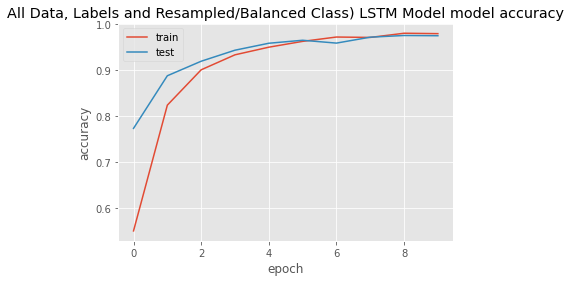

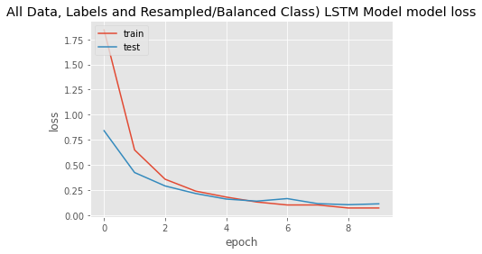

```python
 #LSTM_Model_data_1.plotModelAccuracy(LSTM_Model_data_1_history, 'All Data, Binary Labels and Unsampled (But Balanced Class) LSTM Model')

LSTM_Model_data_3_resampled.plotModelAccuracy(LSTM_Model_data_3_resampled_history, 'All Data, Labels and Resampled/Balanced Class) LSTM Model')
```

```python
results=captureData(results,LSTM_Model_data_3_resampled_history,'LSTM_Model_data_3_resampled','LSTM Model + Word2Vec Embedding on data_3_resampled Dataset','1',0)
pred_results= capturePrediction(pred_results,'LSTM_Model_data_3_resamp1ed','LSTM Model + Word2Vec Embedding on data_3_resampled Dataset','1',LSTM_Model_data_3_resampled_accuracy,0)
```

```python
results
```

|  | model | val_accuracy | val_loss | loss | accuracy | descriptions |
| --- | --- | --- | --- | --- | --- | --- |
| 1 | LSTM_Model_data_3_resampled | 0.975487 | 0.104182 | 0.071478 | 0.980358 | LSTM Model + Word2Vec Embedding on data_3_resa... |

```python
pred_results
```

|  | model | Pred_Accuracy | descriptions |
| --- | --- | --- | --- |
| 1 | LSTM_Model_data_3_resamp1ed | 0.974963 | LSTM Model + Word2Vec Embedding on data_3_resa... |

Note: LSTM model with Word2Vec Embedding on dataset 3 with resampled data gave validation accuracy of 0.97 and training accuracy of 98.03. The model is not overfitting. LSTM with Glove embedding is also tested below. We plan to also explore potential visualisation options in the next iteration.

# DL MODEL 2: LSTM [GloVe] [DATASET 3]

```python
maxlen = 300
numWords=9000
epochs = 10
embed_size = 200
LSTM_Model_data_3_resampled_Glove = LSTM_Model_GloVe()
```

```python
start = time.time()
LSTM_Model_data_3_resampled_Glove_history, model = LSTM_Model_data_3_resampled_Glove.train(data_3_resampled.sample(frac = 1) ,embed_size,epochs)
time.sleep(1)
end = time.time()
print(f"Time Taken To Train LSTM on dataset 3 with labels: {end - start}")
```

```
Number of Samples: 47730
Number of Labels:  47730
Number of train Samples: 30547
Number of val Samples: 7637
Model: "functional_11"
_________________________________________________________________
Layer (type)                 Output Shape              Param #
=================================================================
input_6 (InputLayer)         [(None, 300)]             0
_________________________________________________________________
embedding_5 (Embedding)      (None, 300, 200)          1800200
_________________________________________________________________
bidirectional_5 (Bidirection (None, 256)               336896
_________________________________________________________________
dropout_5 (Dropout)          (None, 256)               0
_________________________________________________________________
dense_10 (Dense)             (None, 100)               25700
_________________________________________________________________
dense_11 (Dense)             (None, 74)                7474
=================================================================
Total params: 2,170,270
Trainable params: 2,170,270
Non-trainable params: 0
_________________________________________________________________
Epoch 00001: val_accuracy improved from -inf to 0.74087, saving model to model-001-0.740867.h5
Epoch 00002: val_accuracy improved from 0.74087 to 0.85989, saving model to model-002-0.859893.h5
Epoch 00003: val_accuracy improved from 0.85989 to 0.91541, saving model to model-003-0.915412.h5
Epoch 00004: val_accuracy improved from 0.91541 to 0.94448, saving model to model-004-0.944481.h5
Epoch 00005: val_accuracy improved from 0.94448 to 0.95548, saving model to model-005-0.955480.h5
Epoch 00006: val_accuracy improved from 0.95548 to 0.96609, saving model to model-006-0.966086.h5
Epoch 00007: val_accuracy improved from 0.96609 to 0.96622, saving model to model-007-0.966217.h5
Epoch 00008: val_accuracy improved from 0.96622 to 0.97329, saving model to model-008-0.973288.h5
Epoch 00009: val_accuracy improved from 0.97329 to 0.97420, saving model to model-009-0.974205.h5
Epoch 00010: val_accuracy improved from 0.97420 to 0.97617, saving model to model-010-0.976169.h5
Time Taken To Train LSTM on dataset 3 with labels: 177.45189332962036
```

```python
import pydotplus as pydot
import graphviz
from tensorflow import keras
from tensorflow.keras.utils import plot_model
#plot_model(LSTM_Model_data_3_resampled, to_file='LSTM_Model_data_3_resampled.png', show_shapes=True, show_layer_names=True)
```

```python
LSTM_Model_data_3_resampled_Glove_accuracy = LSTM_Model_data_3_resampled_Glove.prediction()
```

```
Accuracy of the model : 0.9724491933794259
```

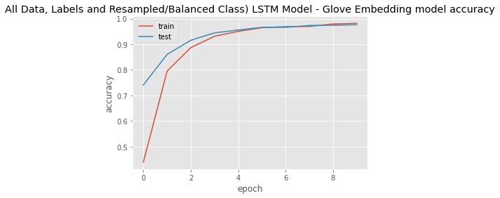

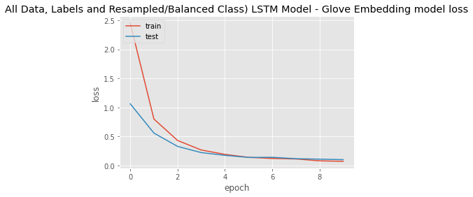

```python
LSTM_Model_data_3_resampled_Glove.plotModelAccuracy(LSTM_Model_data_3_resampled_Glove_history, 'All Data, Labels and Resampled/Balanced Class) LSTM Model - Glove Embedding')
```

```python
results=captureData(results,LSTM_Model_data_3_resampled_Glove_history,'LSTM_Model_data_3_resampled_Glove','LSTM Model + Glove Embedding on data_3_resampled Dataset','1',0)
pred_results= capturePrediction(pred_results,'LSTM_Model_data_3_resamp1ed_Glove','LSTM Model + Glove Embedding on data_3_resampled Dataset','1',LSTM_Model_data_3_resampled_Glove_accuracy,0)
```

```python
results
```

|  | model | val_accuracy | val_loss | loss | accuracy | descriptions |
| --- | --- | --- | --- | --- | --- | --- |
| 1 | LSTM_Model_data_3_resampled | 0.975487 | 0.104182 | 0.071478 | 0.980358 | LSTM Model + Word2Vec Embedding on data_3_resa... |
| 1 | LSTM_Model_data_3_resampled_Glove | 0.976169 | 0.099261 | 0.070182 | 0.981668 | LSTM Model + Glove Embedding on data_3_resampl... |

```python
pred_results
```

|  | model | Pred_Accuracy | descriptions |
| --- | --- | --- | --- |
| 1 | LSTM_Model_data_3_resamp1ed | 0.974963 | LSTM Model + Word2Vec Embedding on data_3_resa... |
| 1 | LSTM_Model_data_3_resamp1ed_Glove | 0.972449 | LSTM Model + Glove Embedding on data_3_resampl... |

Note: LSTM Model with glove embedding is also analyzed. The trining and test accuracies are similar. Model is not over fitting. There is not much difference with word to vect and glove embedding tried with LSTM model. Word Embedding is the efficient way for text data vectorization and we have used both Word2Vec and GloVe embedding to experiment with the models. The first one is shallow two layer NN trained on large corpus of text to produce a vector for a text (each word) in the corpus. GloVe is unsupervised learning based vector representation of words. The training is performed on an aggregated global word-word co-occurrence statistics from a corpus and the resulting representations have linear substructures of the words in the vector space. We have explored both the types of embedding with LSTM model. We have not encountered significant difference in terms of its impact on the model performance as seen from above.

# DL MODEL 3: Gated Recurrent Unit (GRU) [GloVe] [DATASET 3]

Note: GRU (Gated Recurrent Unit) aims to solve the vanishing gradient problem which comes with a standard recurrent neural network. It can also be considered as a variation on the LSTM because both are designed similarly and, in some cases, produce equally excellent results. This model got rid of the cell state and used the hidden state to transfer information. It uses only 2 gates, update gate and reset gate. Basically, these are two vectors which decide what information should be passed to the output. The update gate acts similar to the forget and input gate of an LSTM. It decides what information to throw away and what new information to add. The reset gate is another gate used to decide how much past information to forget. GRU’s has fewer tensor operations; therefore, they are a little speedier to train than LSTM’s.

```python
maxlen = 300
numWords=9000
epochs = 10
embed_size = 200
LSTM_Model_data_3_resampled_Glove_GRU = LSTM_Model_GloVe_GRU()
```

```python
start = time.time()
LSTM_Model_data_3_resampled_Glove_GRU_history, model = LSTM_Model_data_3_resampled_Glove_GRU.train(data_3_resampled.sample(frac = 1) ,embed_size,epochs)
time.sleep(1)
end = time.time()
print(f"Time Taken To Train LSTM on data_1 dataset with labels: {end - start}")
```

```
Number of Samples: 47730
Number of Labels:  47730
Number of train Samples: 30547
Number of val Samples: 7637
Model: "functional_15"
_________________________________________________________________
Layer (type)                 Output Shape              Param #
=================================================================
input_8 (InputLayer)         [(None, 300)]             0
_________________________________________________________________
embedding_7 (Embedding)      (None, 300, 200)          1800200
_________________________________________________________________
gru_1 (GRU)                  (None, 128)               126720
_________________________________________________________________
dropout_7 (Dropout)          (None, 128)               0
_________________________________________________________________
dense_14 (Dense)             (None, 100)               12900
_________________________________________________________________
dense_15 (Dense)             (None, 74)                7474
=================================================================
Total params: 1,947,294
Trainable params: 1,947,294
Non-trainable params: 0
_________________________________________________________________
Epoch 00001: val_accuracy improved from -inf to 0.73052, saving model to model-001-0.730522.h5
Epoch 00002: val_accuracy improved from 0.73052 to 0.88608, saving model to model-002-0.886081.h5
Epoch 00003: val_accuracy improved from 0.88608 to 0.92968, saving model to model-003-0.929684.h5
Epoch 00004: val_accuracy improved from 0.92968 to 0.94802, saving model to model-004-0.948016.h5
Epoch 00005: val_accuracy improved from 0.94802 to 0.95705, saving model to model-005-0.957051.h5
Epoch 00006: val_accuracy improved from 0.95705 to 0.96059, saving model to model-006-0.960587.h5
Epoch 00007: val_accuracy did not improve from 0.96059
Epoch 00008: val_accuracy improved from 0.96059 to 0.96949, saving model to model-008-0.969491.h5
Epoch 00009: val_accuracy improved from 0.96949 to 0.97211, saving model to model-009-0.972109.h5
Epoch 00010: val_accuracy improved from 0.97211 to 0.97290, saving model to model-010-0.972895.h5
Time Taken To Train LSTM on data_1 dataset with labels: 107.17652750015259
```

```python
import pydotplus as pydot
import graphviz
from tensorflow import keras
from tensorflow.keras.utils import plot_model
#plot_model(LSTM_Model_data_3_resampled, to_file='LSTM_Model_data_3_resampled.png', show_shapes=True, show_layer_names=True)
```

```python
LSTM_Model_data_3_resampled_Glove_GRU_accuracy = LSTM_Model_data_3_resampled_Glove_GRU.prediction()
```

```
Accuracy of the model : 0.9704588309239472
```

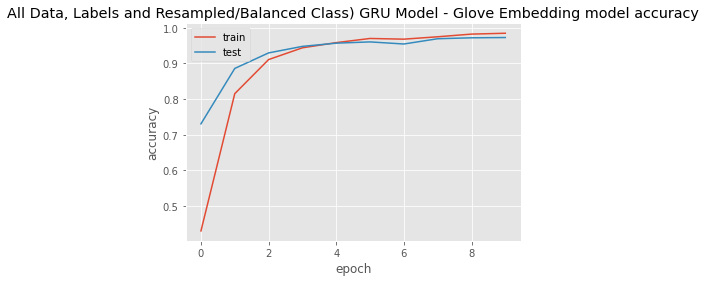

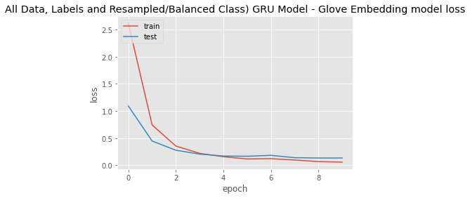

```python
LSTM_Model_data_3_resampled_Glove_GRU.plotModelAccuracy(LSTM_Model_data_3_resampled_Glove_GRU_history, 'All Data, Labels and Resampled/Balanced Class) GRU Model - Glove Embedding')
```

```python
results=captureData(results,LSTM_Model_data_3_resampled_Glove_GRU_history,'LSTM_Model_data_3_resampled_Glove_GRU','GRU Model + Glove Embedding on data_3_resampled Dataset','1',0)
pred_results= capturePrediction(pred_results,'LSTM_Model_data_3_resamp1ed_Glove_GRU','GRU Model + Glove Embedding on data_3_resampled Dataset','1',LSTM_Model_data_3_resampled_Glove_accuracy,0)
```

```python
results
```

|  | model | val_accuracy | val_loss | loss | accuracy | descriptions |
| --- | --- | --- | --- | --- | --- | --- |
| 1 | LSTM_Model_data_3_resampled | 0.975487 | 0.104182 | 0.071478 | 0.980358 | LSTM Model + Word2Vec Embedding on data_3_resa... |
| 1 | LSTM_Model_data_3_resampled_Glove | 0.976169 | 0.099261 | 0.070182 | 0.981668 | LSTM Model + Glove Embedding on data_3_resampl... |
| 1 | LSTM_Model_data_3_resampled_Glove_GRU | 0.972895 | 0.133801 | 0.057786 | 0.984909 | GRU Model + Glove Embedding on data_3_resample... |

```python
pred_results
```

|  | model | Pred_Accuracy | descriptions |
| --- | --- | --- | --- |
| 1 | LSTM_Model_data_3_resamp1ed | 0.974963 | LSTM Model + Word2Vec Embedding on data_3_resa... |
| 1 | LSTM_Model_data_3_resamp1ed_Glove | 0.972449 | LSTM Model + Glove Embedding on data_3_resampl... |
| 1 | LSTM_Model_data_3_resamp1ed_Glove_GRU | 0.972449 | GRU Model + Glove Embedding on data_3_resample... |

The GRU model gave accuracies similar to LSTM. The model is not overfitting as well.

# DL MODEL 4: RNN [GloVe] [DATASET 3]

Note: Recurrent Neural Networks (RNNs) are a family of neural networks designed specifically for sequential data processing. The RNN model does prediction of the next word in a sequence based on the previous ones. This operation is performed recurrently which is why it is called as Recurrent Neural Networks. It repetitively performs the same task for every element of a sequence, with the output being dependent on the previous computations. In short it has a memory of the text used in a sequence used for classification of the text both from the type of texts and the sequence of appearance as well. There are known inherent issues in RNN which are addressed in the subsequent model of LSTM.

```python
maxlen = 300
numWords=9000
epochs = 10
embed_size = 200
RNN_Model_data_3_resampled_Glove = RNN_Model_GloVe()
```

```python
start = time.time()
RNN_Model_data_3_resampled_Glove_history, RNN_model = RNN_Model_data_3_resampled_Glove.train(data_3_resampled.sample(frac =.03) ,embed_size,epochs)
time.sleep(1)
end = time.time()
print(f"Time Taken To Train RNN on data_1 dataset with labels: {end - start}")
```

```
Number of Samples: 1432
Number of Labels:  1432
Number of train Samples: 1145
Number of val Samples: 287
Model: "sequential"
_________________________________________________________________
Layer (type)                 Output Shape              Param #
=================================================================
embedding_8 (Embedding)      (None, 300, 200)          1800200
_________________________________________________________________
conv1d (Conv1D)              (None, 291, 100)          200100
_________________________________________________________________
max_pooling1d (MaxPooling1D) (None, 145, 100)          0
_________________________________________________________________
dropout_8 (Dropout)          (None, 145, 100)          0
_________________________________________________________________
conv1d_1 (Conv1D)            (None, 136, 100)          100100
_________________________________________________________________
max_pooling1d_1 (MaxPooling1 (None, 68, 100)           0
_________________________________________________________________
bidirectional_6 (Bidirection (None, 256)               234496
_________________________________________________________________
dropout_9 (Dropout)          (None, 256)               0
_________________________________________________________________
dense_16 (Dense)             (None, 100)               25700
_________________________________________________________________
dense_17 (Dense)             (None, 74)                7474
=================================================================
Total params: 2,368,070
Trainable params: 2,368,070
Non-trainable params: 0
_________________________________________________________________
Epoch 00001: val_accuracy improved from -inf to 0.04878, saving model to model-001-0.048780.h5
Epoch 00002: val_accuracy improved from 0.04878 to 0.08362, saving model to model-002-0.083624.h5
Epoch 00003: val_accuracy improved from 0.08362 to 0.12195, saving model to model-003-0.121951.h5
Epoch 00004: val_accuracy improved from 0.12195 to 0.13240, saving model to model-004-0.132404.h5
Epoch 00005: val_accuracy improved from 0.13240 to 0.19861, saving model to model-005-0.198606.h5
Epoch 00006: val_accuracy improved from 0.19861 to 0.25087, saving model to model-006-0.250871.h5
Epoch 00007: val_accuracy improved from 0.25087 to 0.26829, saving model to model-007-0.268293.h5
Epoch 00008: val_accuracy improved from 0.26829 to 0.30662, saving model to model-008-0.306620.h5
Epoch 00009: val_accuracy improved from 0.30662 to 0.35540, saving model to model-009-0.355401.h5
Epoch 00010: val_accuracy improved from 0.35540 to 0.42509, saving model to model-010-0.425087.h5
Time Taken To Train RNN on data_1 dataset with labels: 13.183300256729126
```

```python
import pydotplus as pydot
import graphviz
from tensorflow import keras
from tensorflow.keras.utils import plot_model
#plot_model(RNN_Model_data_3_resampled_Glove, to_file='RNN_Model_data_3_resampled_Glove.png', show_shapes=True, show_layer_names=True)
```

```python
RNN_Model_data_3_resampled_Glove_accuracy = RNN_Model_data_3_resampled_Glove.prediction(RNN_model)
```

```
Accuracy of the model : 0.4250871080139373
```

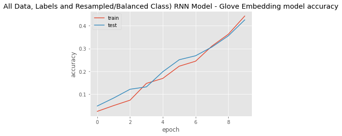

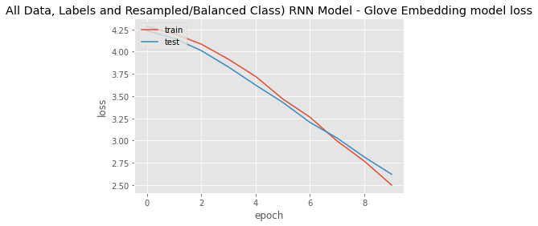

```python
RNN_Model_data_3_resampled_Glove.plotModelAccuracy(RNN_Model_data_3_resampled_Glove_history, 'All Data, Labels and Resampled/Balanced Class) RNN Model - Glove Embedding')
```

```python
results=captureData(results,RNN_Model_data_3_resampled_Glove_history,'RNN_Model_data_3_resampled_Glove','RNN Model + Glove Embedding on data_3_resampled Dataset','1',0)
pred_results= capturePrediction(pred_results,'RNN_Model_data_3_resamp1ed_Glove','RNN Model + Glove Embedding on data_3_resampled Dataset','1',RNN_Model_data_3_resampled_Glove_accuracy,0)
```

```python
results
```

|  | model | val_accuracy | val_loss | loss | accuracy | descriptions |
| --- | --- | --- | --- | --- | --- | --- |
| 1 | LSTM_Model_data_3_resampled | 0.975487 | 0.104182 | 0.071478 | 0.980358 | LSTM Model + Word2Vec Embedding on data_3_resa... |
| 1 | LSTM_Model_data_3_resampled_Glove | 0.976169 | 0.099261 | 0.070182 | 0.981668 | LSTM Model + Glove Embedding on data_3_resampl... |
| 1 | LSTM_Model_data_3_resampled_Glove_GRU | 0.972895 | 0.133801 | 0.057786 | 0.984909 | GRU Model + Glove Embedding on data_3_resample... |
| 1 | RNN_Model_data_3_resampled_Glove | 0.425087 | 2.621301 | 2.499696 | 0.441921 | RNN Model + Glove Embedding on data_3_resample... |

```python
pred_results
```

|  | model | Pred_Accuracy | descriptions |
| --- | --- | --- | --- |
| 1 | LSTM_Model_data_3_resamp1ed | 0.974963 | LSTM Model + Word2Vec Embedding on data_3_resa... |
| 1 | LSTM_Model_data_3_resamp1ed_Glove | 0.972449 | LSTM Model + Glove Embedding on data_3_resampl... |
| 1 | LSTM_Model_data_3_resamp1ed_Glove_GRU | 0.972449 | GRU Model + Glove Embedding on data_3_resample... |
| 1 | RNN_Model_data_3_resamp1ed_Glove | 0.425087 | RNN Model + Glove Embedding on data_3_resample... |

Note: RNN model gave traing accuracy of 44.19 % and testing accuracy of 42.50 %. The model is not overfitting either. We would like further tweak with its architecture in the next iteration.

# TRANSFORMER MODE : BERT + DATASET 3

Note: BERT is a method of pre-training language representations, meaning that we train a general-purpose "language understanding" model on a large text corpus (like Wikipedia), and then use that model for downstream NLP tasks that we care about (like question answering). BERT outperforms previous methods because it is the first unsupervised, deeply bidirectional system for pre-training NLP. Unsupervised means that BERT was trained using only a plain text corpus, which is important because an enormous amount of plain text data is publicly available on the web in many languages. Pre-trained representations can also either be context-free or contextual, and contextual representations can further be unidirectional or bidirectional. Context-free models such as word2vec or GloVe generate a single "word embedding" representation for each word in the vocabulary, so bank would have the same representation in bank deposit and river bank. Contextual models instead generate a representation of each word that is based on the other words in the sentence. https://github.com/google-research/bert/blob/master/README.md

```python
!pip install ktrain
```

[output not shown]

```python
#Bert Model using KTrain
import ktrain
from ktrain import text
```

```python
(x_train, y_train), (x_test, y_test), preproc = text.texts_from_df(data_3_resampled,
                                                                   'Description', # name of column containing review text
                                                                   label_columns=['Assignment group'],
                                                                   maxlen=250,
                                                                   max_features=10000,
                                                                   preprocess_mode='bert',
                                                                   val_pct=0.1,
                                                                   ngram_range=3)
```

```python
model = text.text_classifier('bert', train_data=(x_train, y_train), preproc=preproc)
learner = ktrain.get_learner(model, train_data=(x_train, y_train), batch_size=6)
```

```python
learner.fit_onecycle(2e-5, 8)
```

```python
y_test_back = [i.argmax() for i in y_test]
```

```python
learner.validate(val_data=(x_test, y_test), class_names=np.unique(y_test_back).all())
```

```python
predictor = ktrain.get_predictor(learner.model, preproc)
```

```python
predictor.get_classes()
```

```python
test_data.iloc[144]
```

```python
test_labels.iloc[144]
```

```python
#predictor.predict(test_data.iloc[1484].astype(str).values.tolist())
predictor.predict(test_data.iloc[144])
```

```python
# let's save the predictor for later use
predictor.save(os.path.join(capstone_project_path,'/my_predictor'))
```

```python
# reload the predictor
reloaded_predictor = ktrain.load_predictor(os.path.join(capstone_project_path,'/my_predictor'))
```

```python
reloaded_predictor.predict(test_data.iloc[54].astype(str).values.tolist())
```

```python
print(test_labels.iloc[54])
```

# ML MODEL 1 : RANDOM FOREST CLASSIFIER + DATASET 3

Note: Tree based models work by learning in hierarchical manner. Random forests is a supervised learning algorithm which can be used both for classification as well as regression. It is also the most flexible and easy to use algorithm. It creates decision trees on randomly selected data samples, gets prediction from each tree and selects the best solution by means of voting. It also provides a pretty good indicator of the feature importance.

```python
def wordTokenizer(dataframe):
    tokenizer = Tokenizer(num_words=numWords,filters='!"#$%&()*+,-./:;<=>?@[\\]^_`{|}~\t\n',lower=True,split=' ', char_level=False)
    tokenizer.fit_on_texts(dataframe)
    dataframe = tokenizer.texts_to_sequences(dataframe)
    return tokenizer,dataframe
```

```python
data_3_resampled.reset_index(drop=True, inplace=True)
data_3_resampled.head(2).T
```

|  | 0 | 1 |
| --- | --- | --- |
| Short description | collaboration_platform site is not opening | account locked. |
| Description | collaboration_platform site opening | account lock . |
| Caller | anpocezt qturbxsg | bkyphsgq cfyksehu |
| Assignment group | GRP_0 | GRP_0 |
| New_Assignment_Groups | 0 | 0 |
| Text_length | 42 | 15 |

```python
data_3_resampled.columns[1],data_3_resampled.columns[4]
```

```
('Description', 'New_Assignment_Groups')
```

```python
maxlen = 150
numWords = 9000
```

```python
tokenizer,X = wordTokenizer(data_3_resampled[data_3_resampled.columns[1]])
```

```python
y = np.asarray(data_3_resampled[data_3_resampled.columns[4]])
X = pad_sequences(X, maxlen = maxlen)
```

```python
print("Number of Samples:", len(X))
print("Number of Labels: ", len(y))
```

```
Number of Samples: 47730
Number of Labels:  47730
```

```python
X_train, X_test, y_train, y_test = train_test_split(X, y, test_size=0.2, random_state=10)
```

```python
print("Number of Training Samples:", len(X_train))
print("Number of Validation Samples:", len(X_test))
```

```
Number of Training Samples: 38184
Number of Validation Samples: 9546
```

```python
data_3_resampled_RFC=RandomForestClassifier(n_estimators=100)
```

```python
start = time.time()
data_3_resampled_RFC.fit(X_train,y_train)
time.sleep(1)
end = time.time()
print(f"Time Taken To Train RFC on dataset 3 : {end - start}")
```

```
Time Taken To Train RFC on dataset 3 : 7.925279140472412
```

```python
y_pred=data_3_resampled_RFC.predict(X_test)
```

```python
print("Accuracy:",metrics.accuracy_score(y_test, y_pred))
```

```
Accuracy: 0.9836580766813325
```

```python
print(classification_report(y_test, data_3_resampled_RFC.predict(X_test), digits=4))
```

```
              precision    recall  f1-score   support

           0     0.8929    0.5137    0.6522       146
           1     0.9746    1.0000    0.9871       115
           2     0.9695    1.0000    0.9845       127
           3     0.9922    1.0000    0.9961       127
           4     0.9137    0.9270    0.9203       137
           5     0.9030    0.9918    0.9453       122
           6     0.9431    1.0000    0.9707       116
           7     1.0000    1.0000    1.0000       135
           8     0.9507    1.0000    0.9747       135
           9     0.9660    1.0000    0.9827       142
          10     0.9851    1.0000    0.9925       132
          11     0.8966    0.9541    0.9244       109
          12     0.8651    0.9316    0.8971       117
```

[output cut: 65 more lines]

```python
results_ML_Models = pd.DataFrame()
results_data_3_resampled_RFC = pd.DataFrame({'Model':['Random Forest'], 'accuracy': [metrics.accuracy_score(y_test, y_pred)]},index={'1'})
results_ML_Models = pd.concat([results_ML_Models, results_data_3_resampled_RFC])
results_ML_Models
```

|  | Model | accuracy |
| --- | --- | --- |
| 1 | Random Forest | 0.983658 |

# ML MODEL 2 : RANDOM FOREST CLASSIFIER [WEIGHTED] + DATASET 3

```python
def wordTokenizer(dataframe):
    tokenizer = Tokenizer(num_words=numWords,filters='!"#$%&()*+,-./:;<=>?@[\\]^_`{|}~\t\n',lower=True,split=' ', char_level=False)
    tokenizer.fit_on_texts(dataframe)
    dataframe = tokenizer.texts_to_sequences(dataframe)
    return tokenizer,dataframe

data_3_resampled.reset_index(drop=True, inplace=True)
data_3_resampled.head(2).T

data_3_resampled.columns[1],data_3_resampled.columns[4]

maxlen = 150
numWords = 9000

tokenizer,X = wordTokenizer(data_3_resampled[data_3_resampled.columns[1]])

y = np.asarray(data_3_resampled[data_3_resampled.columns[4]])
X = pad_sequences(X, maxlen = maxlen)

print("Number of Samples:", len(X))
print("Number of Labels: ", len(y))


X_train, X_test, y_train, y_test = train_test_split(X, y, test_size=0.2, random_state=10)

print("Number of Training Samples:", len(X_train))
print("Number of Validation Samples:", len(X_test))

data_3_resampled_RFC_W = RandomForestClassifier(n_estimators=100, criterion = 'entropy', class_weight='balanced') # Class Weights

start = time.time()
data_3_resampled_RFC_W.fit(X_train,y_train)
time.sleep(1)
end = time.time()
print(f"Time Taken To Train RFC Weighted on dataset 3: {end - start}")

y_pred=data_3_resampled_RFC_W.predict(X_test)

print("Accuracy:",metrics.accuracy_score(y_test, y_pred))

print(classification_report(y_test, data_3_resampled_RFC_W.predict(X_test), digits=4))

#results_ML_Models = pd.DataFrame()
results_data_3_resampled_RFC_W = pd.DataFrame({'Model':['Random Forest Classifier - Weighted'], 'accuracy': [metrics.accuracy_score(y_test, y_pred)]},index={'1'})
results_ML_Models = pd.concat([results_ML_Models, results_data_3_resampled_RFC_W])
results_ML_Models
```

```
Number of Samples: 47730
Number of Labels:  47730
Number of Training Samples: 38184
Number of Validation Samples: 9546
Time Taken To Train RFC Weighted on dataset 3: 13.761258125305176
Accuracy: 0.9847056358684265
              precision    recall  f1-score   support

           0     0.8384    0.5685    0.6776       146
           1     0.9914    1.0000    0.9957       115
           2     0.9769    1.0000    0.9883       127
           3     0.9922    1.0000    0.9961       127
           4     0.8811    0.9197    0.9000       137
           5     0.9380    0.9918    0.9641       122
           6     0.9748    1.0000    0.9872       116
```

[output cut: 71 more lines]

|  | Model | accuracy |
| --- | --- | --- |
| 1 | Random Forest | 0.983658 |
| 1 | Random Forest Classifier - Weighted | 0.984706 |

Note: We have received good accuracy using RFC. Also there is not much difference between with and without assigning the class weights which we plan to explore further.

# ML MODEL 3 : Adaboost + DATASET 3

```python
def wordTokenizer(dataframe):
    tokenizer = Tokenizer(num_words=numWords,filters='!"#$%&()*+,-./:;<=>?@[\\]^_`{|}~\t\n',lower=True,split=' ', char_level=False)
    tokenizer.fit_on_texts(dataframe)
    dataframe = tokenizer.texts_to_sequences(dataframe)
    return tokenizer,dataframe

data_3_resampled.reset_index(drop=True, inplace=True)
data_3_resampled.head(2).T

data_3_resampled.columns[1],data_3_resampled.columns[4]

maxlen = 150
numWords = 9000

tokenizer,X = wordTokenizer(data_3_resampled[data_3_resampled.columns[1]])

y = np.asarray(data_3_resampled[data_3_resampled.columns[4]])
X = pad_sequences(X, maxlen = maxlen)

print("Number of Samples:", len(X))
print("Number of Labels: ", len(y))


X_train, X_test, y_train, y_test = train_test_split(X, y, test_size=0.2, random_state=10)

print("Number of Training Samples:", len(X_train))
print("Number of Validation Samples:", len(X_test))


from sklearn.ensemble import AdaBoostClassifier

data_3_resampled_Ada = AdaBoostClassifier(n_estimators=100, learning_rate=0.1, algorithm='SAMME.R', random_state=22)

start = time.time()
data_3_resampled_Ada.fit(X_train,y_train)
time.sleep(1)
end = time.time()
print(f"Time Taken To Train Adaboost on dataset 3 : {end - start}")

y_pred=data_3_resampled_Ada.predict(X_test)

print("Accuracy:",metrics.accuracy_score(y_test, y_pred))

print(classification_report(y_test, data_3_resampled_Ada.predict(X_test), digits=4))

#results_ML_Models = pd.DataFrame()
results_data_3_resampled_Ada= pd.DataFrame({'Model':['Adaboost Classifier'], 'accuracy': [metrics.accuracy_score(y_test, y_pred)]},index={'1'})
results_ML_Models = pd.concat([results_ML_Models, results_data_3_resampled_Ada])
results_ML_Models
```

```
Number of Samples: 47730
Number of Labels:  47730
Number of Training Samples: 38184
Number of Validation Samples: 9546
Time Taken To Train Adaboost on dataset 3 : 19.890626907348633
Accuracy: 0.1256023465325791
              precision    recall  f1-score   support

           0     0.0599    0.3904    0.1038       146
           1     0.0000    0.0000    0.0000       115
           2     0.0000    0.0000    0.0000       127
           3     0.0000    0.0000    0.0000       127
           4     0.0314    0.1241    0.0501       137
           5     0.0183    0.0820    0.0299       122
           6     0.0252    0.0690    0.0370       116
```

[output cut: 71 more lines]

|  | Model | accuracy |
| --- | --- | --- |
| 1 | Random Forest | 0.983658 |
| 1 | Random Forest Classifier - Weighted | 0.984706 |
| 1 | Adaboost Classifier | 0.125602 |

# ML MODEL 4 : BAGGING + DATASET 3

```python
def wordTokenizer(dataframe):
    tokenizer = Tokenizer(num_words=numWords,filters='!"#$%&()*+,-./:;<=>?@[\\]^_`{|}~\t\n',lower=True,split=' ', char_level=False)
    tokenizer.fit_on_texts(dataframe)
    dataframe = tokenizer.texts_to_sequences(dataframe)
    return tokenizer,dataframe

data_3_resampled.reset_index(drop=True, inplace=True)
data_3_resampled.head(2).T

data_3_resampled.columns[1],data_3_resampled.columns[4]

maxlen = 150
numWords = 9000

tokenizer,X = wordTokenizer(data_3_resampled[data_3_resampled.columns[1]])

y = np.asarray(data_3_resampled[data_3_resampled.columns[4]])
X = pad_sequences(X, maxlen = maxlen)

print("Number of Samples:", len(X))
print("Number of Labels: ", len(y))


X_train, X_test, y_train, y_test = train_test_split(X, y, test_size=0.2, random_state=10)

print("Number of Training Samples:", len(X_train))
print("Number of Validation Samples:", len(X_test))


from sklearn.ensemble import BaggingClassifier

data_3_resampled_Bagg= BaggingClassifier(n_estimators=200, oob_score=True, bootstrap=True, random_state=22)

start = time.time()
data_3_resampled_Bagg.fit(X_train,y_train)
time.sleep(1)
end = time.time()
print(f"Time Taken To Train Bagging on dataset 3 : {end - start}")

y_pred=data_3_resampled_Bagg.predict(X_test)

print("Accuracy:",metrics.accuracy_score(y_test, y_pred))

print(classification_report(y_test, data_3_resampled_Bagg.predict(X_test), digits=4))

#results_ML_Models = pd.DataFrame()
results_data_3_resampled_Bagg= pd.DataFrame({'Model':['Bagging Classifier'], 'accuracy': [metrics.accuracy_score(y_test, y_pred)]},index={'1'})
results_ML_Models = pd.concat([results_ML_Models, results_data_3_resampled_Bagg])
results_ML_Models
```

```
Number of Samples: 47730
Number of Labels:  47730
Number of Training Samples: 38184
Number of Validation Samples: 9546
Time Taken To Train Bagging on dataset 3 : 148.3569004535675
Accuracy: 0.9831342970877854
              precision    recall  f1-score   support

           0     0.8533    0.4384    0.5792       146
           1     0.9746    1.0000    0.9871       115
           2     0.9845    1.0000    0.9922       127
           3     1.0000    1.0000    1.0000       127
           4     0.8741    0.9124    0.8929       137
           5     0.9528    0.9918    0.9719       122
           6     0.9667    1.0000    0.9831       116
```

[output cut: 71 more lines]

|  | Model | accuracy |
| --- | --- | --- |
| 1 | Random Forest | 0.983658 |
| 1 | Random Forest Classifier - Weighted | 0.984706 |
| 1 | Adaboost Classifier | 0.125602 |
| 1 | Bagging Classifier | 0.983134 |

# ML MODEL 5 : GradientBoost + DATASET 3

```python
def wordTokenizer(dataframe):
    tokenizer = Tokenizer(num_words=numWords,filters='!"#$%&()*+,-./:;<=>?@[\\]^_`{|}~\t\n',lower=True,split=' ', char_level=False)
    tokenizer.fit_on_texts(dataframe)
    dataframe = tokenizer.texts_to_sequences(dataframe)
    return tokenizer,dataframe

data_3_resampled.reset_index(drop=True, inplace=True)
data_3_resampled.head(2).T

data_3_resampled.columns[1],data_3_resampled.columns[4]

maxlen = 150
numWords = 9000

tokenizer,X = wordTokenizer(data_3_resampled[data_3_resampled.columns[1]])

y = np.asarray(data_3_resampled[data_3_resampled.columns[4]])
X = pad_sequences(X, maxlen = maxlen)

print("Number of Samples:", len(X))
print("Number of Labels: ", len(y))


X_train, X_test, y_train, y_test = train_test_split(X, y, test_size=0.2, random_state=10)

print("Number of Training Samples:", len(X_train))
print("Number of Validation Samples:", len(X_test))


from sklearn.ensemble import GradientBoostingClassifier

data_3_resampled_gd= GradientBoostingClassifier(n_estimators=100, learning_rate = 0.05, random_state=22)

start = time.time()
data_3_resampled_gd.fit(X_train,y_train)
time.sleep(1)
end = time.time()
print(f"Time Taken To Train Bagging on dataset 3 : {end - start}")

y_pred=data_3_resampled_gd.predict(X_test)

print("Accuracy:",metrics.accuracy_score(y_test, y_pred))

print(classification_report(y_test, data_3_resampled_gd.predict(X_test), digits=4))

#results_ML_Models = pd.DataFrame()
results_data_3_resampled_gd= pd.DataFrame({'Model':['GradientBoost Classifier'], 'accuracy': [metrics.accuracy_score(y_test, y_pred)]},index={'1'})
results_ML_Models  = pd.concat([results_ML_Models, results_data_3_resampled_gd])
results_ML_Models
```

[output not shown]

# ML MODEL 6 : SVM & SGD CLASSIFIER + DATASET 3

Note: A support vector machine (SVM) is a supervised machine learning model that uses classification algorithms for two-group classification problems. After giving an SVM model sets of labeled training data for each category, they’re able to categorize the new text. It is a fast and dependable classification algorithm that performs very well with a limited amount of data. A popular algorithm for this technique is penalized SVM.

```python
def wordTokenizer(dataframe):
    tokenizer = Tokenizer(num_words=numWords,filters='!"#$%&()*+,-./:;<=>?@[\\]^_`{|}~\t\n',lower=True,split=' ', char_level=False)
    tokenizer.fit_on_texts(dataframe)
    dataframe = tokenizer.texts_to_sequences(dataframe)
    return tokenizer,dataframe
```

```python
data_3_resampled.columns[1],data_3_resampled.columns[4]
```

```
('Description', 'New_Assignment_Groups')
```

```python
maxlen = 150
numWords = 9000
```

```python
tokenizer,X = wordTokenizer(data_3_resampled[data_3_resampled.columns[1]])
```

```python
y = np.asarray(data_3_resampled[data_3_resampled.columns[4]])
X = pad_sequences(X, maxlen = maxlen)
```

```python
print("Number of Samples:", len(X))
print("Number of Labels: ", len(y))
```

```
Number of Samples: 47730
Number of Labels:  47730
```

```python
X_train, X_test, y_train, y_test = train_test_split(X, y, test_size=0.2, random_state=10)
```

```python
print("Number of Training Samples:", len(X_train))
print("Number of Validation Samples:", len(X_test))
```

```
Number of Training Samples: 38184
Number of Validation Samples: 9546
```

```python
data_3_resampled_SVC = svm.SVC(kernel='rbf')
```

```python
Cs = [0.01, 0.1 ] #Cs = [0.01, 0.1, 1, 10]
gammas = [0.001, 0.01 ] #gammas = [0.001, 0.01, 0.1, 1]
param_grid = {'C': Cs, 'gamma' : gammas}
```

```python
# start = time.time()
# grid_search = GridSearchCV(data_3_resampled_SVC, param_grid)
# grid_search.fit(X_train,y_train)
# time.sleep(1)
# end = time.time()
# print(f"Time Taken To Get Best Parameters For SVC on dataset 3 dataset with Grid Search: {end - start}")
```

```python
#data_3_resampled_SVC = svm.SVC(**grid_search.best_params_)
data_3_resampled_SVC = svm.SVC(kernel='rbf', C=.01, gamma=.001)
```

```python
start = time.time()
data_3_resampled_SVC.fit(X_train, y_train)
time.sleep(1)
end = time.time()
print(f"Time Taken To Train SVC on dataset 3 : {end - start}")
```

[output not shown]

```python
y_pred_SVC = data_3_resampled_SVC.predict(X_test) #predictig using SVC Classifier
```

```python
print("Accuracy:",metrics.accuracy_score(y_test, y_pred_SVC))
```

```
Accuracy: 0.2641944269851247
```

```python
print(classification_report(y_test, data_3_resampled_SVC.predict(X_test), digits=4))
```

```
              precision    recall  f1-score   support

           0     0.0000    0.0000    0.0000       146
           1     0.0000    0.0000    0.0000       115
           2     0.0000    0.0000    0.0000       127
           3     0.0000    0.0000    0.0000       127
           4     0.0000    0.0000    0.0000       137
           5     0.0000    0.0000    0.0000       122
           6     0.0000    0.0000    0.0000       116
           7     0.0000    0.0000    0.0000       135
           8     0.0000    0.0000    0.0000       135
           9     0.0000    0.0000    0.0000       142
          10     0.0000    0.0000    0.0000       132
          11     0.0153    1.0000    0.0301       109
          12     0.0000    0.0000    0.0000       117
```

[output cut: 65 more lines]

```python
data_3_resampled_SGD = SGDClassifier()
```

```python
start = time.time()
data_3_resampled_SGD.fit(X_train, y_train)
time.sleep(1)
end = time.time()
print(f"Time Taken To Train SGD on dataset 3 : {end - start}")
```

[output not shown]

```python
y_pred_SGD = data_3_resampled_SGD.predict(X_test) #predicting using SGD Classifier
```

```python
#accuracy_score(y_test,y_pred_SGD) #accuracy score of two models
print("Accuracy:",metrics.accuracy_score(y_test, y_pred_SGD))
```

```
Accuracy: 0.29813534464697256
```

```python
print(classification_report(y_test, data_3_resampled_SGD.predict(X_test), digits=4))
```

```
              precision    recall  f1-score   support

           0     0.0103    0.0137    0.0117       146
           1     0.7609    0.3043    0.4348       115
           2     0.3529    0.0472    0.0833       127
           3     0.1686    0.2283    0.1940       127
           4     0.0642    0.0511    0.0569       137
           5     0.1575    0.1639    0.1606       122
           6     0.0593    0.1810    0.0894       116
           7     0.1677    0.2074    0.1854       135
           8     0.1168    0.1185    0.1176       135
           9     0.3043    0.0986    0.1489       142
          10     0.5714    0.1515    0.2395       132
          11     0.1667    0.0367    0.0602       109
          12     0.0600    0.1282    0.0817       117
```

[output cut: 65 more lines]

```python
#results_ML_Models = pd.DataFrame()
results_data_3_resampled_SVC = pd.DataFrame({'Model':['SVM Classifier'], 'accuracy': [metrics.accuracy_score(y_test, y_pred_SVC)]},index={'2'})
results_data_3_resampled_SGD = pd.DataFrame({'Model':['SGD Classifier'], 'accuracy': [metrics.accuracy_score(y_test, y_pred_SGD)]},index={'2'})
results_ML_Models = pd.concat([results_ML_Models, results_data_3_resampled_SVC])
results_ML_Models = pd.concat([results_ML_Models, results_data_3_resampled_SGD])
results_ML_Models
```

[output not shown]

# ML MODEL 7: NAIVE BAYES + DATASET 3

```python
data_3_resampled.head(2).T
```

|  | 0 | 1 |
| --- | --- | --- |
| Short description | collaboration_platform site is not opening | account locked. |
| Description | collaboration_platform site opening | account lock . |
| Caller | anpocezt qturbxsg | bkyphsgq cfyksehu |
| Assignment group | GRP_0 | GRP_0 |
| New_Assignment_Groups | 0 | 0 |
| Text_length | 42 | 15 |

```python
def wordTokenizer(dataframe):
    tokenizer = Tokenizer(num_words=numWords,filters='!"#$%&()*+,-./:;<=>?@[\\]^_`{|}~\t\n',lower=True,split=' ', char_level=False)
    tokenizer.fit_on_texts(dataframe)
    dataframe = tokenizer.texts_to_sequences(dataframe)
    return tokenizer,dataframe
```

```python
data_3_resampled.columns[1],data_3_resampled.columns[4]
```

```
('Description', 'New_Assignment_Groups')
```

```python
maxlen = 150
numWords = 9000
```

```python
tokenizer,X = wordTokenizer(data_3_resampled[data_3_resampled.columns[1]])
```

```python
X[0]
```

```
[393, 369, 355, 1728]
```

```python
y = np.asarray(data_3_resampled[data_3_resampled.columns[4]])
X = pad_sequences(X, maxlen = maxlen)
```

```python
print("Number of Samples:", len(X))
print("Number of Labels: ", len(y))
```

```
Number of Samples: 47730
Number of Labels:  47730
```

```python
X_train, X_test, y_train, y_test = train_test_split(X, y, test_size=0.2, random_state=10)
```

```python
print("Number of Training Samples:", len(X_train))
print("Number of Validation Samples:", len(X_test))
```

```
Number of Training Samples: 38184
Number of Validation Samples: 9546
```

```python
data_3_resampled_NB = MultinomialNB().fit(X_train, y_train)

y_pred_NB = data_3_resampled_NB.predict(X_test)
```

```python
accuracy_score(y_test,y_pred_NB)
```

```
0.3176199455269223
```

```python
print(classification_report(y_test, data_3_resampled_NB.predict(X_test), digits=4))
```

```
              precision    recall  f1-score   support

           0     0.0000    0.0000    0.0000       146
           1     0.4038    0.1826    0.2515       115
           2     0.1081    0.0315    0.0488       127
           3     1.0000    0.1102    0.1986       127
           4     0.1667    0.0073    0.0140       137
           5     0.0952    0.0820    0.0881       122
           6     0.3333    0.0086    0.0168       116
           7     0.3297    0.2222    0.2655       135
           8     0.1176    0.0296    0.0473       135
           9     0.0555    0.2887    0.0931       142
          10     0.3171    0.0985    0.1503       132
          11     0.0417    0.0092    0.0150       109
          12     0.6000    0.0256    0.0492       117
```

[output cut: 65 more lines]

```python
#results_ML_Models = pd.DataFrame()
results_data_3_resampled_NB = pd.DataFrame({'Model':['MultinomialNB Classifier'], 'accuracy': [metrics.accuracy_score(y_test, y_pred_NB)]},index={'2'})
results_ML_Models = pd.concat([results_ML_Models, results_data_3_resampled_NB])
results_ML_Models
```

|  | Model | accuracy |
| --- | --- | --- |
| 1 | Random Forest | 0.983658 |
| 1 | Random Forest Classifier - Weighted | 0.984706 |
| 1 | Adaboost Classifier | 0.125602 |
| 1 | Bagging Classifier | 0.983134 |
| 2 | MultinomialNB Classifier | 0.317620 |

```python
from sklearn.naive_bayes import ComplementNB

data_3_resampled_CNB = ComplementNB()
data_3_resampled_CNB.fit(X_train, y_train)
```

```
ComplementNB(alpha=1.0, class_prior=None, fit_prior=True, norm=False)
```

```python
y_pred_CNB = data_3_resampled_CNB.predict(X_test)
```

```python
accuracy_score(y_test,y_pred_CNB)
print(classification_report(y_test, data_3_resampled_CNB.predict(X_test), digits=4))
```

```
              precision    recall  f1-score   support

           0     0.0000    0.0000    0.0000       146
           1     0.1032    0.1130    0.1079       115
           2     0.0000    0.0000    0.0000       127
           3     1.0000    0.0472    0.0902       127
           4     0.0000    0.0000    0.0000       137
           5     0.1395    0.0492    0.0727       122
           6     0.0000    0.0000    0.0000       116
           7     0.0862    0.2741    0.1312       135
           8     0.1111    0.0889    0.0988       135
           9     0.2824    0.1690    0.2115       142
          10     0.2121    0.0530    0.0848       132
          11     0.0000    0.0000    0.0000       109
          12     0.0000    0.0000    0.0000       117
```

[output cut: 65 more lines]

```python
#results_ML_Models = pd.DataFrame()
results_data_3_resampled_CNB = pd.DataFrame({'Model':['ComplementNB Classifier'], 'accuracy': [metrics.accuracy_score(y_test, y_pred_CNB)]},index={'2'})
results_ML_Models = pd.concat([results_ML_Models, results_data_3_resampled_CNB])
results_ML_Models
```

|  | Model | accuracy |
| --- | --- | --- |
| 1 | Random Forest | 0.983658 |
| 1 | Random Forest Classifier - Weighted | 0.984706 |
| 1 | Adaboost Classifier | 0.125602 |
| 1 | Bagging Classifier | 0.983134 |
| 2 | MultinomialNB Classifier | 0.317620 |
| 2 | ComplementNB Classifier | 0.136706 |

# ML MODEL 8: KNN + DATASET 3

```python
def wordTokenizer(dataframe):
    tokenizer = Tokenizer(num_words=numWords,filters='!"#$%&()*+,-./:;<=>?@[\\]^_`{|}~\t\n',lower=True,split=' ', char_level=False)
    tokenizer.fit_on_texts(dataframe)
    dataframe = tokenizer.texts_to_sequences(dataframe)
    return tokenizer,dataframe

data_3_resampled.reset_index(drop=True, inplace=True)
data_3_resampled.head(2).T

data_3_resampled.columns[1],data_3_resampled.columns[4]

maxlen = 150
numWords = 9000

tokenizer,X = wordTokenizer(data_3_resampled[data_3_resampled.columns[1]])

y = np.asarray(data_3_resampled[data_3_resampled.columns[4]])
X = pad_sequences(X, maxlen = maxlen)

print("Number of Samples:", len(X))
print("Number of Labels: ", len(y))


X_train, X_test, y_train, y_test = train_test_split(X, y, test_size=0.2, random_state=10)

print("Number of Training Samples:", len(X_train))
print("Number of Validation Samples:", len(X_test))

from sklearn.neighbors import KNeighborsClassifier
scores =[]
# for k in range(1,50):
#     NNH = KNeighborsClassifier(n_neighbors = k, weights = 'uniform', metric='euclidean')
#     NNH.fit(X_train, y_train)
#     scores.append(NNH.score(X_test, y_test))

# plt.plot(range(1,50),scores)

data_3_resampled_KNN = KNeighborsClassifier(n_neighbors= 12 , weights = 'uniform', metric='euclidean')

start = time.time()
data_3_resampled_KNN.fit(X_train,y_train)
time.sleep(1)
end = time.time()
print(f"Time Taken To Train KNN on dataset 3 : {end - start}")

y_pred=data_3_resampled_KNN.predict(X_test)

print("Accuracy:",metrics.accuracy_score(y_test, y_pred))

print(classification_report(y_test, data_3_resampled_KNN.predict(X_test), digits=4))

#results_ML_Models = pd.DataFrame()
results_data_3_resampled_KNN= pd.DataFrame({'Model':['KNN Classifier'], 'accuracy': [metrics.accuracy_score(y_test, y_pred)]},index={'1'})
results_ML_Models  = pd.concat([results_ML_Models, results_data_3_resampled_KNN])
results_ML_Models
```

```
Number of Samples: 47730
Number of Labels:  47730
Number of Training Samples: 38184
Number of Validation Samples: 9546
Time Taken To Train KNN on dataset 3 : 3.7868759632110596
Accuracy: 0.8408757594804106
              precision    recall  f1-score   support

           0     0.6364    0.1438    0.2346       146
           1     0.8582    1.0000    0.9237       115
           2     0.6496    0.5984    0.6230       127
           3     0.8194    1.0000    0.9007       127
           4     0.3111    0.1022    0.1538       137
           5     0.5000    0.3361    0.4020       122
           6     0.4754    0.5000    0.4874       116
```

[output cut: 71 more lines]

|  | Model | accuracy |
| --- | --- | --- |
| 1 | Random Forest | 0.983658 |
| 1 | Random Forest Classifier - Weighted | 0.984706 |
| 1 | Adaboost Classifier | 0.125602 |
| 1 | Bagging Classifier | 0.983134 |
| 2 | MultinomialNB Classifier | 0.317620 |
| 2 | ComplementNB Classifier | 0.136706 |
| 1 | KNN Classifier | 0.840876 |

# Interim Summary

- Exploratory Data Analysis is performed on the data. More details can be referrenced from interim report. Data preprocessing, Data cleaning is done on the data:
- Missing Values & Duplicates : We have dropped duplicate records as they don’t additional information or value for classification. We have replaced the null values a space. There were 83 duplicate records across all columns, 682 duplicate records by the value in Description column and 661 duplicate records having same values in Description and Assignment Group together.
- Upper & Lower Case Text: We have converted the feature set in lower case as this helps simplify addressing the cleaning function through regular expression. Otherwise we would land up building more and more filtering criteria to account for the two different cases. Also the feature data based prediction as such does not influence the classification methods in any way.
- Special Characters & Stop Words : We have removed various characters like hashtags and kept many of them in the concatenated feature set to subject to the cleaning using regular expression. We planned to use the NLTK for removal of stop words.
- Language & Spelling Errors & Lemmatization: We have kept the text as it is. However for experimentation and learning perspective we have tried to translate some of the words from non-English to English. We have also tried correcting some of the typical spelling errors. We have then used lemmatization on the processed or clean text.
- Word Cloud & Topic Modeling & N-Grams: We have used word cloud to visualize the frequently existing words and have also performed topic modeling (using Gensim LDA Model) to understand the correlated words in the text across the incident reports i.e. grouping the tickets or incidents based on the words used in the text. We have also tried to plot the number of words used in each of the tickets to study the outliers.
- Word Embedding & Vectorization: We used Word2Vec and Glove Embedding for vectorization and preparation of dataset.
- The target class imbalance: We have many classes with less than 10 incidents. Resampling is done to handle class imbalances.
- Model Development (please refer accuracies from above or from interim report for more details):
- Deep Learning

[output not shown]

- Machine Learning Models

| Model | Test accuracy |
| --- | --- |
| Random Forest | 0.983658 |
| Random Forest Classifier - Weighted | 0.984706 |
| Adaboost Classifier | 0.125602 |
| Bagging Classifier | 0.983134 |
| MultinomialNB Classifier | 0.317620 |
| ComplementNB Classifier | 0.136706 |
| KNN Classifier | 0.840876 |

# Next Steps (Next Iteration)